# 06_biz_analytics_accepted

**Hello, Jolene!** My name is Grigoriy Gusarov and I'm going to review your project. My main goal is not to show that any mistakes have been made somewhere, but to share my experience that will help you in your further work. Further in the file you can see my comments, try to take them into account when performing the next tasks. **Please, don't delete them.** You can find my comments in green, yellow or red boxes like this:

**Reviewer's comment:** if everything is done succesfully

**Reviewer's comment:** if I can give some recommendations

**Reviewer's comment:** if the block requires some corrections. Work can't be accepted with the red comments.

Let's work on the project in dialogue: if you change something in the project or respond to my comments, write about it. It will be easier for me to track the changes if you highlight your comments:

**Student's comment:** For example like this.

### General feedback

Thank you for sending your project! Great job, you've submitted very solid research. Please, pay attention to the CAC calculations and sub-conclusions.

**Student's comment:** Hi Grigoriy, thank you for reviewing my project. I want to be a good coder, I appreciate your feedback. Your resources and recommendations are really helpful. I've made updates below, I hope this is what you were looking for. Thank you, Jolene G.

**Update**:  
Thank you for the update! Well done, you've solved most of the issues. Please, take a second glance at the CAC part - unfortunately, we still have some issues there. I've left an additional hint below.

**Update**:  
Thank you for the fast response! Splendid, now CAC and ROMI part completely right 💪 Your project has been accepted, congratulations!

**Reviewer's comment:** Additional links:

- Quantitative Economics with Python: https://quantecon.org/python-lectures/
- Style Pandas Dataframe Like a Master: https://towardsdatascience.com/style-pandas-dataframe-like-a-master-6b02bf6468b0
- Lifetime value in Python : https://github.com/CamDavidsonPilon/lifetimes

# Business Analytics Course Project

*Project description*

You've done beautifully in the Practicum course, and you've been offered an internship in the analytical department at Yandex.Afisha. Your first task is to help optimize marketing expenses.

*Tasks*

- Study the following:
  - How people use the product
  - When they start to buy
  - How much money each customer brings
  - When they pay off
- Use the following sources for analysis
  - Use server logs with data on Yandex.Afisha from June 2017 - May 2018
  - Dump file with all orders for the period
  - Marketing expenses statistics

*Instructions for completing the project*

*Step 1. Download the data and prepare it for analysis*

- Store the data on visits, orders, and expenses in variables. Optimize the data for analysis. Make sure each column contains the correct data type.
- Use the following file paths:
  - /datasets/visits_log_us.csv. Download dataset
  - /datasets/orders_log_us.csv. Download dataset
  - /datasets/costs_us.csv. Download dataset

*Step 2. Make reports and calculate metrics:*

- Product
  - How many people use it every day, week, and month?
  - How many sessions are there per day? (One user might have more than one session.)
  - What is the length of each session?
  - How often do users come back?
- Sales
  - When do people start buying? (In KPI analysis, we're usually interested in knowing the time that elapses between registration and conversion — when the user becomes a customer. For example, if registration and the first purchase occur on the same day, the user might fall into category Conversion 0d. If the first purchase happens the next day, it will be Conversion 1d. You can use any approach that lets you compare the conversions of different cohorts, so that you can determine which cohort, or marketing channel, is most effective.)
  - How many orders do they make during a given period of time?
  - What is the average purchase size?
  - How much money do they bring? (LTV)
- Marketing
  - How much money was spent? Overall/per source/over time
  - How much did customer acquisition from each of the sources cost?
  - How worthwhile where the investments? (ROI)
  - Plot graphs to display how these metrics differ for various devices and ad sources and how they change in time.

*Step 3. Write a conclusion: advise marketing experts how much money to invest and where.*

- What sources/platforms would you recommend? Back up your choice: what metrics did you focus on? Why? What conclusions did you draw after finding the metric values?

*Description of the data*

- The visits table (server logs with data on website visits):
  - Uid — user's unique identifier
  - Device — user's device
  - Start Ts — session start date and time
  - End Ts — session end date and time
    - All dates in this table are in YYYY-MM-DD format.
  - Source Id — identifier of the ad source the user came from
- The orders table (data on orders):
  - Uid — unique identifier of the user making an order
  - Buy Ts — order date and time
  - Revenue — Yandex.Afisha's revenue from the order
- The costs table (data on marketing expenses):
  - source_id — ad source identifier
  - dt — date
  - costs — expenses on this ad source on this day

*Plan of Action*

- 1. Import Libraries
- 1. Open the data files and study the general information
- 1. Data Preprocessing
     - Create working versions of the dataframes
     - Clean up the data
- 1. Analyze the data
     - Answer the requested information
- 1. Draw conclusions

**Reviewer's comment:** Nice introduction 👍

# 1. Import Libraries

```python
import pandas as pd
import numpy as np
import matplotlib.pyplot as plt
import datetime
import seaborn as sns

import sys
import warnings
if not sys.warnoptions:
    warnings.simplefilter("ignore")
```

# 2. Open the data files and study the general information

*Read data as dataframes and examine the original data*

```python
# read data as a dataframe
visits_orig = pd.read_csv('/datasets/visits_log_us.csv')
orders_orig = pd.read_csv('/datasets/orders_log_us.csv')
costs_orig = pd.read_csv('/datasets/costs_us.csv')
```

*Examine original visits df*

```python
print('visits df')
visits_orig.head()
```

```
visits df
```

|  | Device | End Ts | Source Id | Start Ts | Uid |
| --- | --- | --- | --- | --- | --- |
| 0 | touch | 2017-12-20 17:38:00 | 4 | 2017-12-20 17:20:00 | 16879256277535980062 |
| 1 | desktop | 2018-02-19 17:21:00 | 2 | 2018-02-19 16:53:00 | 104060357244891740 |
| 2 | touch | 2017-07-01 01:54:00 | 5 | 2017-07-01 01:54:00 | 7459035603376831527 |
| 3 | desktop | 2018-05-20 11:23:00 | 9 | 2018-05-20 10:59:00 | 16174680259334210214 |
| 4 | desktop | 2017-12-27 14:06:00 | 3 | 2017-12-27 14:06:00 | 9969694820036681168 |

```python
print('visits df info')
visits_orig.info()
```

```
visits df info
<class 'pandas.core.frame.DataFrame'>
RangeIndex: 359400 entries, 0 to 359399
Data columns (total 5 columns):
Device       359400 non-null object
End Ts       359400 non-null object
Source Id    359400 non-null int64
Start Ts     359400 non-null object
Uid          359400 non-null uint64
dtypes: int64(1), object(3), uint64(1)
memory usage: 13.7+ MB
```

```python
print("number of unique visitors or Uids (user's unique identifier)")
visits_orig['Uid'].value_counts(dropna=False).count()
```

```
number of unique visitors or Uids (user's unique identifier)
```

```
228169
```

**Reviewer's comment:** Nice idea to annotate your outputs. F-strings could be useful here: https://realpython.com/python-f-strings/#option-1-formatting

**Student's comment:** I will keep this in mind on my next project!

```python
# could maybe make this a graph - would want to include the values
print('device types used')
visits_orig['Device'].value_counts(dropna=False)
```

```
device types used
```

```
desktop    262567
touch       96833
Name: Device, dtype: int64
```

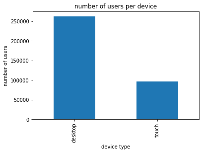

```python
visits_orig['Device'].value_counts(dropna=False).plot(kind='bar')
plt.title('number of users per device')
plt.xlabel('device type')
plt.ylabel('number of users')
plt.show()
```

**Reviewer's comment:** Small hint: you can improve your barplot with values adding. Check this link:https://robertmitchellv.com/blog-bar-chart-annotations-pandas-mpl.html

**Student's comment:** I will have to evaluate this before I incorporate it to my graphs in this project.

**Reviewer's comment:** Please, add chart conclusions. I saw that you have general conclusions after the end of each step (and this is great), but it is not enough. In this case, you force the reader to scroll research up and down, which breaks storytelling logic. So, I recommend you add sub-conclusions after each chart and then summarize them at the end of a step.

**Student's comment:** Chart conclusion: based on the original data set, the desktop device is used much more than the touch device.

```python
print('count of source ids (identifier of the ad source the user came from) used')
visits_orig['Source Id'].value_counts(dropna=False)
```

```
count of source ids (identifier of the ad source the user came from) used
```

```
4     101794
3      85610
5      66905
2      47626
1      34121
9      13277
10     10025
7         36
6          6
Name: Source Id, dtype: int64
```

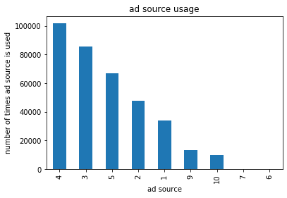

```python
visits_orig['Source Id'].value_counts(dropna=False).plot(kind='bar')
plt.title('ad source usage')
plt.xlabel('ad source')
plt.ylabel('number of times ad source is used')
plt.show()
```

*Examine original orders df*

```python
print('orders df')
orders_orig.head()
```

```
orders df
```

|  | Buy Ts | Revenue | Uid |
| --- | --- | --- | --- |
| 0 | 2017-06-01 00:10:00 | 17.00 | 10329302124590727494 |
| 1 | 2017-06-01 00:25:00 | 0.55 | 11627257723692907447 |
| 2 | 2017-06-01 00:27:00 | 0.37 | 17903680561304213844 |
| 3 | 2017-06-01 00:29:00 | 0.55 | 16109239769442553005 |
| 4 | 2017-06-01 07:58:00 | 0.37 | 14200605875248379450 |

```python
print('orders df info')
orders_orig.info()
```

```
orders df info
<class 'pandas.core.frame.DataFrame'>
RangeIndex: 50415 entries, 0 to 50414
Data columns (total 3 columns):
Buy Ts     50415 non-null object
Revenue    50415 non-null float64
Uid        50415 non-null uint64
dtypes: float64(1), object(1), uint64(1)
memory usage: 1.2+ MB
```

```python
print('number of unique orderers or Uids (unique identifier of the user making an order)')
orders_orig['Uid'].value_counts(dropna=False).count()
```

```
number of unique orderers or Uids (unique identifier of the user making an order)
```

```
36523
```

```python
print('calculated revenue from orders df')
orders_orig['Revenue'].sum().round()
```

```
calculated revenue from orders df
```

```
252057.0
```

*Examine orginal costs df*

```python
print('costs df')
costs_orig.head()
```

```
costs df
```

|  | source_id | dt | costs |
| --- | --- | --- | --- |
| 0 | 1 | 2017-06-01 | 75.20 |
| 1 | 1 | 2017-06-02 | 62.25 |
| 2 | 1 | 2017-06-03 | 36.53 |
| 3 | 1 | 2017-06-04 | 55.00 |
| 4 | 1 | 2017-06-05 | 57.08 |

```python
print('costs df info')
costs_orig.info()
```

```
costs df info
<class 'pandas.core.frame.DataFrame'>
RangeIndex: 2542 entries, 0 to 2541
Data columns (total 3 columns):
source_id    2542 non-null int64
dt           2542 non-null object
costs        2542 non-null float64
dtypes: float64(1), int64(1), object(1)
memory usage: 59.7+ KB
```

```python
print('costs source id (ad source identifier)')
costs_orig['source_id'].value_counts(dropna=False)
```

```
costs source id (ad source identifier)
```

```
5     364
9     363
3     363
1     363
10    363
4     363
2     363
Name: source_id, dtype: int64
```

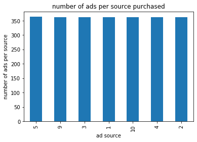

```python
costs_orig['source_id'].value_counts(dropna=False).plot(kind='bar')
plt.title('number of ads per source purchased')
plt.xlabel('ad source')
plt.ylabel('number of ads per source')
plt.show()
```

**Student's comment:** Chart conclusion: based on the original data set, the number of ads purchased per source are equal - ie, one is not purchased more than the other.

```
                costs
                 mean  median    min      max
source_id
1           57.391928   54.71   5.80   245.75
2          117.922975  115.97  15.08   507.09
3          389.315785  353.14  39.26  1788.28
4          168.246832  130.07   0.83   788.03
5          142.189835  137.30   0.70   719.22
9           15.199697   14.49   1.85    49.53
10          16.039917   14.67   0.54    68.11
```

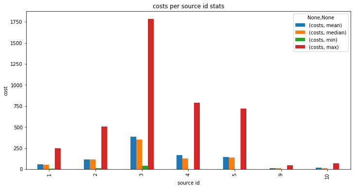

```python
source_id_costs = costs_orig.groupby('source_id').agg(['mean', 'median', 'min', 'max'])
print(source_id_costs)
source_id_costs.plot(kind='bar', figsize = (12, 6))
plt.title('costs per source id stats')
plt.xlabel('source id')
plt.ylabel('cost')
plt.show()
```

**Student's comment:** Chart conclusion: based on the original data set, ad sources 3, 4, 5 have the highest average cost and max costs, followed by 2, 1, 10, 9.

```python
print('calculated costs from costs df')
costs_orig['costs'].sum()
```

```
calculated costs from costs df
```

```
329131.62
```

# 2 Conclusion of original files and general information

*Visits df*

- There are 359400 Yandex.Afisha visits in this data set from 228169 unique visitors
- Two device types were used (desktop and touch)
  - desktop is used a lot more than touch in this data set
- Nine ad sources are in this data set (noted by a number)

*Orders df*

- This data set contains 50415 orders made by 36523 unique users
- The calculated revenue for this data set is 252057

*Costs df*

- This data set contains 2542 cost entries
  - Seven different ad sources are in this data set (noted by a number)
  - Six of the seven have the same number of enties of 363, one of the seven has 364 entries
- The calculated costs for this data set is 329131.62
- The costs of ads ranges from 54 cents to 1788 dollars
  - based on the ad source the average ranges from 15 - 389 dollars

**Reviewer's comment:** Well done, thank you for so deep sub-research. Let's look at the data preparation step.

**Reviewer's comment v2:** Very good, all critical issues have been solved here. And yes, of course, take your time to evaluate optional recommndations.

# 3 Data Preprocessing

*Clean up the data and process where necessary*

- Plan of Action
  - read and save working versions of data - import with datatype changes
  - identify missing values
  - identify duplicate rows
  - create readable/user friendly columns

*Save working versions of the data*

```python
# create working dataframes, import with datatype changes at the same time
visits = pd.read_csv('/datasets/visits_log_us.csv', parse_dates = ['Start Ts', 'End Ts'])
orders = pd.read_csv('/datasets/orders_log_us.csv', parse_dates = ['Buy Ts'])
costs = pd.read_csv('/datasets/costs_us.csv', parse_dates = ['dt'])
```

```python
print('CONFIRM DATATYPE CHANGES - OBJECT TO DATETIME')
print('')
print('visits df info:')
visits.info()
print('')
print('orders df info:')
orders.info()
print('')
print('costs df info:')
costs.info()
```

```
CONFIRM DATATYPE CHANGES - OBJECT TO DATETIME

visits df info:
<class 'pandas.core.frame.DataFrame'>
RangeIndex: 359400 entries, 0 to 359399
Data columns (total 5 columns):
Device       359400 non-null object
End Ts       359400 non-null datetime64[ns]
Source Id    359400 non-null int64
Start Ts     359400 non-null datetime64[ns]
Uid          359400 non-null uint64
dtypes: datetime64[ns](2), int64(1), object(1), uint64(1)
memory usage: 13.7+ MB

orders df info:
<class 'pandas.core.frame.DataFrame'>
RangeIndex: 50415 entries, 0 to 50414
Data columns (total 3 columns):
Buy Ts     50415 non-null datetime64[ns]
Revenue    50415 non-null float64
Uid        50415 non-null uint64
dtypes: datetime64[ns](1), float64(1), uint64(1)
memory usage: 1.2 MB

costs df info:
<class 'pandas.core.frame.DataFrame'>
RangeIndex: 2542 entries, 0 to 2541
Data columns (total 3 columns):
source_id    2542 non-null int64
dt           2542 non-null datetime64[ns]
costs        2542 non-null float64
dtypes: datetime64[ns](1), float64(1), int64(1)
memory usage: 59.7 KB
```

*Identify missing values in each data set*

```python
print('number of missing values in visits df')
visits.isnull().sum()
```

```
number of missing values in visits df
```

```
Device       0
End Ts       0
Source Id    0
Start Ts     0
Uid          0
dtype: int64
```

```python
print('number of missing values in orders df')
orders.isnull().sum()
```

```
number of missing values in orders df
```

```
Buy Ts     0
Revenue    0
Uid        0
dtype: int64
```

```python
print('number of missing values in costs df')
costs.isnull().sum()
```

```
number of missing values in costs df
```

```
source_id    0
dt           0
costs        0
dtype: int64
```

*Identify duplicate rows in each data set*

```python
print('number of duplicate rows in visits df')
visits.duplicated().sum()
```

```
number of duplicate rows in visits df
```

```
0
```

```python
print('number of duplicate rows in orders df')
visits.duplicated().sum()
```

```
number of duplicate rows in orders df
```

```
0
```

```python
print('number of duplicate rows in costs df')
visits.duplicated().sum()
```

```
number of duplicate rows in costs df
```

```
0
```

*Create readable/user friendly columns*

```python
visits = visits.rename(columns={'Uid': 'user_id', 'Device': 'device_type', 'Start Ts': 'session_start', 'End Ts': 'session_end', 'Source Id': 'source_id'})
visits.columns
```

```
Index(['device_type', 'session_end', 'source_id', 'session_start', 'user_id'], dtype='object')
```

```python
orders = orders.rename(columns={'Uid': 'user_id', 'Buy Ts': 'order_datetime', 'Revenue': 'revenue'})
orders.columns
```

```
Index(['order_datetime', 'revenue', 'user_id'], dtype='object')
```

```python
costs = costs.rename(columns={'dt': 'ad_datetime', 'costs': 'ad_cost'})
costs.columns
```

```
Index(['source_id', 'ad_datetime', 'ad_cost'], dtype='object')
```

**Student's comment:** Deleting extra row in orders dataset - which caused a extra month in the ltv analysis.

```python
# end of orders dataset before deletion
orders.tail(3)
```

|  | order_datetime | revenue | user_id |
| --- | --- | --- | --- |
| 50412 | 2018-05-31 23:54:00 | 0.30 | 1786462140797698849 |
| 50413 | 2018-05-31 23:56:00 | 3.67 | 3993697860786194247 |
| 50414 | 2018-06-01 00:02:00 | 3.42 | 83872787173869366 |

```python
# delete the last row of dataset
orders.drop(orders.index[-1], inplace = True)
# end of orders dataset after deletion
orders.tail(3)
```

|  | order_datetime | revenue | user_id |
| --- | --- | --- | --- |
| 50411 | 2018-05-31 23:50:00 | 5.80 | 11369640365507475976 |
| 50412 | 2018-05-31 23:54:00 | 0.30 | 1786462140797698849 |
| 50413 | 2018-05-31 23:56:00 | 3.67 | 3993697860786194247 |

# 3 Data Preprocessing Conclusion

*Actions Performed*

- Created a working version of dataframes & parsed dates to change from object type to datetime type
- Cleaned up the data
  - Looked for missing values
    - none were found
  - Looked for duplicate rows
    - none were found
  - Renamed columns to be readable / user friendly

**Reviewer's comment:** Splendid, you've covered all necessary steps!

# 4 Analyze the Data

*Answer the requested information*

*Step 2. Make reports and calculate metrics:*

- Product
  - How many people use it every day, week, and month?
  - How many sessions are there per day? (One user might have more than one session.)
  - What is the length of each session?
  - How often do users come back?
- Sales
  - When do people start buying? (In KPI analysis, we're usually interested in knowing the time that elapses between registration and conversion — when the user becomes a customer. For example, if registration and the first purchase occur on the same day, the user might fall into category Conversion 0d. If the first purchase happens the next day, it will be Conversion 1d. You can use any approach that lets you compare the conversions of different cohorts, so that you can determine which cohort, or marketing channel, is most effective.)
  - How many orders do they make during a given period of time?
  - What is the average purchase size?
  - How much money do they bring? (LTV)
- Marketing
  - How much money was spent? Overall/per source/over time
  - How much did customer acquisition from each of the sources cost?
  - How worthwhile where the investments? (ROI)
  - Plot graphs to display how these metrics differ for various devices and ad sources and how they change in time.

# 4a Product Data Analysis

*Examine the website use*

- Product
  - How many people use it every day, week, and month?
    - create necessary columns
    - find vanity metrics: DAU, WAU, MAU
    - find averages of the vanity metrics
  - How many sessions are there per day? (One user might have more than one session.)
    - calculate the average
    - evaluate the stats
  - What is the length of each session?
    - create necessary columns
    - calculate the average with and with out 0 second sessions
      - evaluate the stats
  - How often do users come back?
    - calculate the weekly and monthly sticky factors

*How many people use the website every day, week, and month?*

- create necessary columns
- find vanity metrics: DAU, WAU, MAU
- find averages of the vanity metrics

```python
# determine use of the website
# create new columns breaking down the session use
visits['session_date'] = pd.to_datetime(visits['session_start'].dt.date)
visits['session_week'] = visits['session_start'].dt.week
visits['session_month'] = visits['session_start'].astype('datetime64[M]')

visits.head()
```

|  | device_type | session_end | source_id | session_start | user_id | session_date | session_week | session_month |
| --- | --- | --- | --- | --- | --- | --- | --- | --- |
| 0 | touch | 2017-12-20 17:38:00 | 4 | 2017-12-20 17:20:00 | 16879256277535980062 | 2017-12-20 | 51 | 2017-12-01 |
| 1 | desktop | 2018-02-19 17:21:00 | 2 | 2018-02-19 16:53:00 | 104060357244891740 | 2018-02-19 | 8 | 2018-02-01 |
| 2 | touch | 2017-07-01 01:54:00 | 5 | 2017-07-01 01:54:00 | 7459035603376831527 | 2017-07-01 | 26 | 2017-07-01 |
| 3 | desktop | 2018-05-20 11:23:00 | 9 | 2018-05-20 10:59:00 | 16174680259334210214 | 2018-05-20 | 20 | 2018-05-01 |
| 4 | desktop | 2017-12-27 14:06:00 | 3 | 2017-12-27 14:06:00 | 9969694820036681168 | 2017-12-27 | 52 | 2017-12-01 |

**Reviewer's comment:** Please, pay attention to how you extract timestamps. It's safer to do it with `astype` and `datetime64[Y]`, `datetime64[M]`, `datetime64[W]`. This gives you not just a number, but a complete date. This is important because even in this project, the data is slightly out of the time frame of one year. And if we were looking at multiple years of data, all the week and month numbers would get mixed up.

**Student's comment:** checked the info before and after extracting timestamps with astype.

**Reviewer's comment v2:** Ok

```python
#v2
visits.info()
```

```
<class 'pandas.core.frame.DataFrame'>
RangeIndex: 359400 entries, 0 to 359399
Data columns (total 8 columns):
device_type      359400 non-null object
session_end      359400 non-null datetime64[ns]
source_id        359400 non-null int64
session_start    359400 non-null datetime64[ns]
user_id          359400 non-null uint64
session_date     359400 non-null datetime64[ns]
session_week     359400 non-null int64
session_month    359400 non-null datetime64[ns]
dtypes: datetime64[ns](4), int64(2), object(1), uint64(1)
memory usage: 21.9+ MB
```

```python
# v2
# determine use of the website
# create new columns breaking down the session use
# visits['session_date'] = pd.to_datetime(visits['session_start'].dt.date)
visits['session_date_D'] = pd.to_datetime(visits['session_start'].astype('datetime64[D]'))

# visits['session_week'] = visits['session_start'].dt.week
visits['session_week_W'] = visits['session_start'].astype('datetime64[W]')

visits['session_month'] = visits['session_start'].astype('datetime64[M]')

visits.head()
```

|  | device_type | session_end | source_id | session_start | user_id | session_date | session_week | session_month | session_date_D | session_week_W |
| --- | --- | --- | --- | --- | --- | --- | --- | --- | --- | --- |
| 0 | touch | 2017-12-20 17:38:00 | 4 | 2017-12-20 17:20:00 | 16879256277535980062 | 2017-12-20 | 51 | 2017-12-01 | 2017-12-20 | 2017-12-14 |
| 1 | desktop | 2018-02-19 17:21:00 | 2 | 2018-02-19 16:53:00 | 104060357244891740 | 2018-02-19 | 8 | 2018-02-01 | 2018-02-19 | 2018-02-15 |
| 2 | touch | 2017-07-01 01:54:00 | 5 | 2017-07-01 01:54:00 | 7459035603376831527 | 2017-07-01 | 26 | 2017-07-01 | 2017-07-01 | 2017-06-29 |
| 3 | desktop | 2018-05-20 11:23:00 | 9 | 2018-05-20 10:59:00 | 16174680259334210214 | 2018-05-20 | 20 | 2018-05-01 | 2018-05-20 | 2018-05-17 |
| 4 | desktop | 2017-12-27 14:06:00 | 3 | 2017-12-27 14:06:00 | 9969694820036681168 | 2017-12-27 | 52 | 2017-12-01 | 2017-12-27 | 2017-12-21 |

```python
# v2
visits.info()
```

```
<class 'pandas.core.frame.DataFrame'>
RangeIndex: 359400 entries, 0 to 359399
Data columns (total 10 columns):
device_type       359400 non-null object
session_end       359400 non-null datetime64[ns]
source_id         359400 non-null int64
session_start     359400 non-null datetime64[ns]
user_id           359400 non-null uint64
session_date      359400 non-null datetime64[ns]
session_week      359400 non-null int64
session_month     359400 non-null datetime64[ns]
session_date_D    359400 non-null datetime64[ns]
session_week_W    359400 non-null datetime64[ns]
dtypes: datetime64[ns](6), int64(2), object(1), uint64(1)
memory usage: 27.4+ MB
```

**Student's comment:** added a few more columns to have the updated data types for date columns while preserving the original table

```python
# find the number of unique daily users
dau_total = visits.groupby('session_date').agg({'user_id': 'nunique'}).reset_index()
dau_total.columns = ['session_date', 'num_daily_users']
dau_total.head()
```

|  | session_date | num_daily_users |
| --- | --- | --- |
| 0 | 2017-06-01 | 605 |
| 1 | 2017-06-02 | 608 |
| 2 | 2017-06-03 | 445 |
| 3 | 2017-06-04 | 476 |
| 4 | 2017-06-05 | 820 |

```python
# find the average number of daily users
dau_avg = dau_total['num_daily_users'].mean()
print(int(dau_avg.round()), 'average daily users')
```

```
908 average daily users
```

```python
# find the number of unique weekly users
wau_total = visits.groupby('session_week').agg({'user_id': 'nunique'}).reset_index()
wau_total.columns = ['session_week', 'num_weekly_users']
wau_total.head()
```

|  | session_week | num_weekly_users |
| --- | --- | --- |
| 0 | 1 | 6918 |
| 1 | 2 | 6703 |
| 2 | 3 | 6972 |
| 3 | 4 | 7060 |
| 4 | 5 | 8111 |

```python
# find the average number of weekly users
wau_avg = wau_total['num_weekly_users'].mean()
print(int(wau_avg.round()), 'average weekly users')
```

```
5825 average weekly users
```

```python
# find the number of unique monthly users
mau_total = visits.groupby('session_month').agg({'user_id': 'nunique'}).reset_index()
mau_total.columns = ['session_month', 'num_monthly_users']
mau_total
```

|  | session_month | num_monthly_users |
| --- | --- | --- |
| 0 | 2017-06-01 | 13259 |
| 1 | 2017-07-01 | 14183 |
| 2 | 2017-08-01 | 11631 |
| 3 | 2017-09-01 | 18975 |
| 4 | 2017-10-01 | 29692 |
| 5 | 2017-11-01 | 32797 |
| 6 | 2017-12-01 | 31557 |
| 7 | 2018-01-01 | 28716 |
| 8 | 2018-02-01 | 28749 |
| 9 | 2018-03-01 | 27473 |
| 10 | 2018-04-01 | 21008 |
| 11 | 2018-05-01 | 20701 |

```python
# find the average monthly users
mau_avg = mau_total['num_monthly_users'].mean()
print(int(mau_avg.round()), 'average monthly users')
```

```
23228 average monthly users
```

**Reviewer's comment:** Good, all metrics are correct.

*How many sessions are there per day? (One user might have more than one session.)*

- calculate the average
- evaluate the stats

```python
daily_sessions = visits.groupby('session_date').agg({'user_id': 'count'}).reset_index()
daily_sessions.columns = ['session_date', 'sessions_per_day']
daily_sessions.head()
```

|  | session_date | sessions_per_day |
| --- | --- | --- |
| 0 | 2017-06-01 | 664 |
| 1 | 2017-06-02 | 658 |
| 2 | 2017-06-03 | 477 |
| 3 | 2017-06-04 | 510 |
| 4 | 2017-06-05 | 893 |

```python
print(int(daily_sessions['sessions_per_day'].mean().round()), 'average number of sessions per day')
```

```
987 average number of sessions per day
```

```python
print('daily session stats')
daily_sessions.describe()
```

```
daily session stats
```

|  | sessions_per_day |
| --- | --- |
| count | 364.000000 |
| mean | 987.362637 |
| std | 418.994796 |
| min | 1.000000 |
| 25% | 635.500000 |
| 50% | 1003.000000 |
| 75% | 1280.000000 |
| max | 4042.000000 |

*What is the length of each session?*

- create necessary columns
- calculate the average with and with out 0 second sessions
  - evaluate the stats

```python
# create a new column containing session length
visits['session_length_minutes'] = (visits['session_end'] - visits['session_start']).dt.seconds / 60
visits.head()
```

|  | device_type | session_end | source_id | session_start | user_id | session_date | session_week | session_month | session_date_D | session_week_W | session_length_minutes |
| --- | --- | --- | --- | --- | --- | --- | --- | --- | --- | --- | --- |
| 0 | touch | 2017-12-20 17:38:00 | 4 | 2017-12-20 17:20:00 | 16879256277535980062 | 2017-12-20 | 51 | 2017-12-01 | 2017-12-20 | 2017-12-14 | 18.0 |
| 1 | desktop | 2018-02-19 17:21:00 | 2 | 2018-02-19 16:53:00 | 104060357244891740 | 2018-02-19 | 8 | 2018-02-01 | 2018-02-19 | 2018-02-15 | 28.0 |
| 2 | touch | 2017-07-01 01:54:00 | 5 | 2017-07-01 01:54:00 | 7459035603376831527 | 2017-07-01 | 26 | 2017-07-01 | 2017-07-01 | 2017-06-29 | 0.0 |
| 3 | desktop | 2018-05-20 11:23:00 | 9 | 2018-05-20 10:59:00 | 16174680259334210214 | 2018-05-20 | 20 | 2018-05-01 | 2018-05-20 | 2018-05-17 | 24.0 |
| 4 | desktop | 2017-12-27 14:06:00 | 3 | 2017-12-27 14:06:00 | 9969694820036681168 | 2017-12-27 | 52 | 2017-12-01 | 2017-12-27 | 2017-12-21 | 0.0 |

```python
print(int(visits['session_length_minutes'].mean().round()), 'minutes is the average session length')
sess_len_non_zeros = visits.query('session_length_minutes > 0.0')
#sess_len_non_zeros.head()
print(int(sess_len_non_zeros['session_length_minutes'].mean().round()), 'minutes is average session length excluding session times of 0')
```

```
11 minutes is the average session length
12 minutes is average session length excluding session times of 0
```

**Reviewer's comment:** Incorrect average metric selection. I recommend you to plots this distribution, you'll see the issue.

**Student's comment:** looked at the distribution - recalcuated the mode to get the most often session length.

**Reviewer's comment v2:** Nice choice, mode is optimal here!

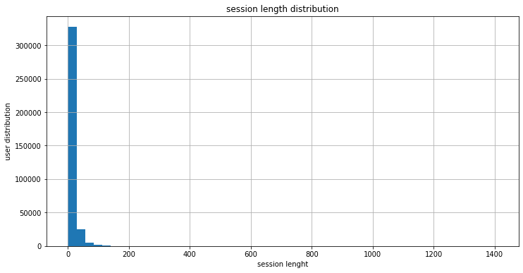

```python
# plot the distribution to determine the best metric for session length
visits['session_length_minutes'].hist(bins = 50, figsize = (12, 6))
plt.title('session length distribution')
plt.xlabel('session lenght')
plt.ylabel('user distribution')
plt.show()
```

```python
# update the calculations with using the mode instead of the mean
# print(int(visits['session_length_minutes'].mean().round()), 'minutes is the average session length')
print(int(visits['session_length_minutes'].mode()), 'minute(s) is the average session length')
sess_len_non_zeros = visits.query('session_length_minutes > 0.0')
#sess_len_non_zeros.head()
# print(int(sess_len_non_zeros['session_length_minutes'].mean().round()), 'minutes is average session length excluding session times of 0')
print(int(sess_len_non_zeros['session_length_minutes'].mode()), 'minute(s) is average session length excluding session times of 0')
```

```
1 minute(s) is the average session length
1 minute(s) is average session length excluding session times of 0
```

**Student's comment:** Session Length Conclusion: using the mode to determine session length, most sessions last for 1 minute. Based on the type of website, it seems like users can accomplish the purpose of the visit quickly.

```python
print('session length (excluding session times of 0) stats')
sess_len_non_zeros['session_length_minutes'].describe()
```

```
session length (excluding session times of 0) stats
```

```
count    323606.000000
mean         11.911410
std          17.450880
min           0.316667
25%           2.000000
50%           6.000000
75%          15.000000
max        1408.000000
Name: session_length_minutes, dtype: float64
```

*Examined data calculated above including and excluding session times of 0*

```python
non_zero_dau = sess_len_non_zeros.groupby('session_date').agg({'user_id': 'nunique'}).reset_index()
non_zero_dau.columns = ['session_date', 'num_daily_users_no_zeros']
dau_avg_no_zeros = non_zero_dau['num_daily_users_no_zeros'].mean()
print(int(dau_avg_no_zeros.round()), 'average daily users excluding session times of 0')
print(int(dau_avg.round()), 'average daily users includes all session times')
print(100 - int(dau_avg_no_zeros.round()) / int(dau_avg.round()) * 100, '% daily users with session times of 0')
print('')

non_zero_wau = sess_len_non_zeros.groupby('session_week').agg({'user_id': 'nunique'}).reset_index()
non_zero_wau.columns = ['session_week', 'num_weekly_users_no_zeros']
wau_avg_no_zeros = non_zero_wau['num_weekly_users_no_zeros'].mean()
print(int(wau_avg_no_zeros.round()), 'average weekly users excluding session times of 0')
print(int(wau_avg.round()), 'average weekly users includes all session times')
print(100 - int(wau_avg_no_zeros.round()) / int(wau_avg.round()) * 100, '% weekly users with session times of 0')
print('')

non_zero_mau = sess_len_non_zeros.groupby('session_month').agg({'user_id': 'nunique'}).reset_index()
non_zero_mau.columns = ['session_month', 'num_monthly_users_no_zeros']
mau_avg_no_zeros = non_zero_mau['num_monthly_users_no_zeros'].mean()
print(int(mau_avg_no_zeros.round()), 'average monthly users excluding session times of 0')
print(int(mau_avg.round()), 'average monthly users includes all session times')
print(100 - int(mau_avg_no_zeros.round()) / int(mau_avg.round()) * 100, '% monthly users with session times of 0')
```

```
818 average daily users excluding session times of 0
908 average daily users includes all session times
9.911894273127757 % daily users with session times of 0

5247 average weekly users excluding session times of 0
5825 average weekly users includes all session times
9.922746781115876 % weekly users with session times of 0

20956 average monthly users excluding session times of 0
23228 average monthly users includes all session times
9.78129843292578 % monthly users with session times of 0
```

*How often do users come back?*

- calculate the weekly and monthly sticky factors

```python
# I would include a 'come back' to count for anyone who came back but still had a session time of 0
# calculate the weekly and monthly sticky factors
print((dau_avg / wau_avg * 100).round(2), '% users return weekly')
print((dau_avg / mau_avg * 100).round(2), '% users return monthly')
```

```
15.59 % users return weekly
3.91 % users return monthly
```

**Reviewer's comment:** Sticky factors were optional, great that you've added them!

**Reviewer's comment:** This part assumes retention rate cohort analysis. Please, add it.

**Student's comment:** calculated monthly retention rates.

```python
visits.head(2)
```

|  | device_type | session_end | source_id | session_start | user_id | session_date | session_week | session_month | session_date_D | session_week_W | session_length_minutes |
| --- | --- | --- | --- | --- | --- | --- | --- | --- | --- | --- | --- |
| 0 | touch | 2017-12-20 17:38:00 | 4 | 2017-12-20 17:20:00 | 16879256277535980062 | 2017-12-20 | 51 | 2017-12-01 | 2017-12-20 | 2017-12-14 | 18.0 |
| 1 | desktop | 2018-02-19 17:21:00 | 2 | 2018-02-19 16:53:00 | 104060357244891740 | 2018-02-19 | 8 | 2018-02-01 | 2018-02-19 | 2018-02-15 | 28.0 |

```python
# create a first session month column and change datatypes
first_month_info = visits.groupby('user_id').agg({'session_date_D': 'min'}).reset_index()
first_month_info.columns = ['user_id', 'first_session_date']
first_month_info['first_session_month'] = first_month_info['first_session_date'].astype('datetime64[M]')
first_month_info.head()
```

|  | user_id | first_session_date | first_session_month |
| --- | --- | --- | --- |
| 0 | 11863502262781 | 2018-03-01 | 2018-03-01 |
| 1 | 49537067089222 | 2018-02-06 | 2018-02-01 |
| 2 | 297729379853735 | 2017-06-07 | 2017-06-01 |
| 3 | 313578113262317 | 2017-09-18 | 2017-09-01 |
| 4 | 325320750514679 | 2017-09-30 | 2017-09-01 |

```python
# create a table to use for calculating retention info
retention_info = pd.merge(visits, first_month_info, on = 'user_id')
retention_info.head()
```

|  | device_type | session_end | source_id | session_start | user_id | session_date | session_week | session_month | session_date_D | session_week_W | session_length_minutes | first_session_date | first_session_month |
| --- | --- | --- | --- | --- | --- | --- | --- | --- | --- | --- | --- | --- | --- |
| 0 | touch | 2017-12-20 17:38:00 | 4 | 2017-12-20 17:20:00 | 16879256277535980062 | 2017-12-20 | 51 | 2017-12-01 | 2017-12-20 | 2017-12-14 | 18.0 | 2017-12-20 | 2017-12-01 |
| 1 | desktop | 2018-02-19 17:21:00 | 2 | 2018-02-19 16:53:00 | 104060357244891740 | 2018-02-19 | 8 | 2018-02-01 | 2018-02-19 | 2018-02-15 | 28.0 | 2018-02-19 | 2018-02-01 |
| 2 | touch | 2017-07-01 01:54:00 | 5 | 2017-07-01 01:54:00 | 7459035603376831527 | 2017-07-01 | 26 | 2017-07-01 | 2017-07-01 | 2017-06-29 | 0.0 | 2017-07-01 | 2017-07-01 |
| 3 | desktop | 2018-05-20 11:23:00 | 9 | 2018-05-20 10:59:00 | 16174680259334210214 | 2018-05-20 | 20 | 2018-05-01 | 2018-05-20 | 2018-05-17 | 24.0 | 2018-03-09 | 2018-03-01 |
| 4 | desktop | 2018-03-09 20:33:00 | 4 | 2018-03-09 20:05:00 | 16174680259334210214 | 2018-03-09 | 10 | 2018-03-01 | 2018-03-09 | 2018-03-08 | 28.0 | 2018-03-09 | 2018-03-01 |

```python
# calculate cohort age
retention_info['cohort_age'] = retention_info['session_month'] - retention_info['first_session_month']
retention_info['cohort_age'] = ((retention_info['cohort_age'] / np.timedelta64(1, 'M')).round()).astype('int')
retention_info.head()
```

|  | device_type | session_end | source_id | session_start | user_id | session_date | session_week | session_month | session_date_D | session_week_W | session_length_minutes | first_session_date | first_session_month | cohort_age |
| --- | --- | --- | --- | --- | --- | --- | --- | --- | --- | --- | --- | --- | --- | --- |
| 0 | touch | 2017-12-20 17:38:00 | 4 | 2017-12-20 17:20:00 | 16879256277535980062 | 2017-12-20 | 51 | 2017-12-01 | 2017-12-20 | 2017-12-14 | 18.0 | 2017-12-20 | 2017-12-01 | 0 |
| 1 | desktop | 2018-02-19 17:21:00 | 2 | 2018-02-19 16:53:00 | 104060357244891740 | 2018-02-19 | 8 | 2018-02-01 | 2018-02-19 | 2018-02-15 | 28.0 | 2018-02-19 | 2018-02-01 | 0 |
| 2 | touch | 2017-07-01 01:54:00 | 5 | 2017-07-01 01:54:00 | 7459035603376831527 | 2017-07-01 | 26 | 2017-07-01 | 2017-07-01 | 2017-06-29 | 0.0 | 2017-07-01 | 2017-07-01 | 0 |
| 3 | desktop | 2018-05-20 11:23:00 | 9 | 2018-05-20 10:59:00 | 16174680259334210214 | 2018-05-20 | 20 | 2018-05-01 | 2018-05-20 | 2018-05-17 | 24.0 | 2018-03-09 | 2018-03-01 | 2 |
| 4 | desktop | 2018-03-09 20:33:00 | 4 | 2018-03-09 20:05:00 | 16174680259334210214 | 2018-03-09 | 10 | 2018-03-01 | 2018-03-09 | 2018-03-08 | 28.0 | 2018-03-09 | 2018-03-01 | 0 |

```python
# calculate cohort size
cohort_size = retention_info.groupby(['first_session_month', 'cohort_age']).agg({'user_id': 'nunique'}).reset_index()
cohort_size.columns = ['first_session_month', 'cohort_age', 'cohort_users']
cohort_size.head()
```

|  | first_session_month | cohort_age | cohort_users |
| --- | --- | --- | --- |
| 0 | 2017-06-01 | 0 | 13259 |
| 1 | 2017-06-01 | 1 | 1043 |
| 2 | 2017-06-01 | 2 | 713 |
| 3 | 2017-06-01 | 3 | 814 |
| 4 | 2017-06-01 | 4 | 909 |

```python
# calculate the number of initial users at the beginning of each cohort
start_cohort_size = cohort_size[cohort_size['cohort_age'] == 0][['first_session_month', 'cohort_users']]
start_cohort_size = start_cohort_size.rename(columns = {'cohort_users': 'initial_cohort_size'})
display(start_cohort_size)
```

|  | first_session_month | initial_cohort_size |
| --- | --- | --- |
| 0 | 2017-06-01 | 13259 |
| 12 | 2017-07-01 | 13140 |
| 23 | 2017-08-01 | 10181 |
| 33 | 2017-09-01 | 16704 |
| 42 | 2017-10-01 | 25977 |
| 50 | 2017-11-01 | 27248 |
| 57 | 2017-12-01 | 25268 |
| 63 | 2018-01-01 | 22624 |
| 68 | 2018-02-01 | 22197 |
| 72 | 2018-03-01 | 20589 |
| 75 | 2018-04-01 | 15709 |
| 77 | 2018-05-01 | 15273 |

```python
# combine the tables
retention_info = pd.merge(cohort_size, start_cohort_size, on = 'first_session_month')
display(retention_info.head())
```

|  | first_session_month | cohort_age | cohort_users | initial_cohort_size |
| --- | --- | --- | --- | --- |
| 0 | 2017-06-01 | 0 | 13259 | 13259 |
| 1 | 2017-06-01 | 1 | 1043 | 13259 |
| 2 | 2017-06-01 | 2 | 713 | 13259 |
| 3 | 2017-06-01 | 3 | 814 | 13259 |
| 4 | 2017-06-01 | 4 | 909 | 13259 |

```python
# calculate the retention
retention_info['retention'] = retention_info['cohort_users'] / retention_info['initial_cohort_size']
retention_info.head()
```

|  | first_session_month | cohort_age | cohort_users | initial_cohort_size | retention |
| --- | --- | --- | --- | --- | --- |
| 0 | 2017-06-01 | 0 | 13259 | 13259 | 1.000000 |
| 1 | 2017-06-01 | 1 | 1043 | 13259 | 0.078664 |
| 2 | 2017-06-01 | 2 | 713 | 13259 | 0.053775 |
| 3 | 2017-06-01 | 3 | 814 | 13259 | 0.061392 |
| 4 | 2017-06-01 | 4 | 909 | 13259 | 0.068557 |

```python
# create a table of retention rates
retention_table = retention_info.pivot_table(index = 'first_session_month', columns = 'cohort_age', values = 'retention', aggfunc = 'sum')
retention_table.fillna('')
```

| cohort_age first_session_month | 0 | 1 | 2 | 3 | 4 | 5 | 6 | 7 | 8 | 9 | 10 | 11 |
| --- | --- | --- | --- | --- | --- | --- | --- | --- | --- | --- | --- | --- |
| 2017-06-01 | 1.0 | 0.0786635 | 0.0537748 | 0.0613923 | 0.0685572 | 0.0714232 | 0.0610152 | 0.0577721 | 0.0523418 | 0.0508334 | 0.0406516 | 0.0449506 |
| 2017-07-01 | 1.0 | 0.0560883 | 0.0512938 | 0.0561644 | 0.0582192 | 0.0481735 | 0.0453577 | 0.0457382 | 0.0388128 | 0.0286149 | 0.0274734 |  |
| 2017-08-01 | 1.0 | 0.076908 | 0.0628622 | 0.062764 | 0.0500933 | 0.0440035 | 0.0363422 | 0.0394853 | 0.0278951 | 0.0260289 |  |  |
| 2017-09-01 | 1.0 | 0.0854885 | 0.069205 | 0.0507064 | 0.0393918 | 0.0378352 | 0.0358597 | 0.0241858 | 0.0228089 |  |  |  |
| 2017-10-01 | 1.0 | 0.078608 | 0.0522385 | 0.0389575 | 0.0342611 | 0.0322208 | 0.0213651 | 0.0203642 |  |  |  |  |
| 2017-11-01 | 1.0 | 0.078281 | 0.0441133 | 0.0386817 | 0.0337272 | 0.0234146 | 0.0217998 |  |  |  |  |  |
| 2017-12-01 | 1.0 | 0.0558018 | 0.0379927 | 0.0311065 | 0.0202628 | 0.0190359 |  |  |  |  |  |  |
| 2018-01-01 | 1.0 | 0.0597153 | 0.0393388 | 0.0249735 | 0.020244 |  |  |  |  |  |  |  |
| 2018-02-01 | 1.0 | 0.0570798 | 0.0254539 | 0.0200928 |  |  |  |  |  |  |  |  |
| 2018-03-01 | 1.0 | 0.0418184 | 0.0270533 |  |  |  |  |  |  |  |  |  |
| 2018-04-01 | 1.0 | 0.0483799 |  |  |  |  |  |  |  |  |  |  |
| 2018-05-01 | 1.0 |  |  |  |  |  |  |  |  |  |  |  |

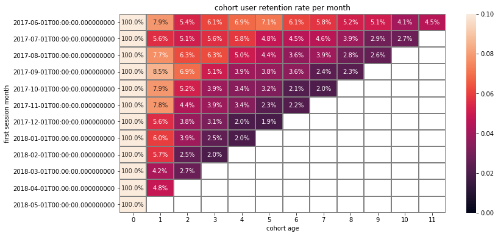

```python
# plot the table of retention rates
plt.figure(figsize=(12, 6))
sns.heatmap(retention_table, annot=True, fmt='.1%', linewidths=1, linecolor='gray', vmin = 0, vmax = 0.1)
plt.title('cohort user retention rate per month')
plt.xlabel('cohort age')
plt.ylabel('first session month')
plt.show()
```

**Student's comment:** Conclusion retention rates: the monthly retention rate per cohort is very low, 9% or less in the first month and it decreases in the following months. This implies that the product or reason for returning to this website is not necessary for all users - this website is for ordering concert tickets and most people dont go to concerts every month, so this makes sense.

**Reviewer's comment v2:** Very good, cohort retention rate is also correct.

# 4a Product Data Analysis Conclusions

*Note, if I were able, I would ask for clarification about how users with a session time of 0 should be handled before these analysis were performed. Since this was not possible, I performed calculations with them*

- users with session times of 0 account for about 10% of the users in this data set
- For example: should a session time of 0 be considered in the DAU, WAU and MAU calculations or the daily sessions?
- I do consider it appropriate to include in how often users come back, because this means they came back, they just didnt do anything.

*How many people use it every day, week, and month?*

- Actions Performed
  - created columns for the session date, week and month
  - the aveage DAU, WAU, and MAU were calculated
- Conclusions
  - DAU - 908 average daily users
  - WAU - 5825 average weekly users
  - MAU - 23228 average monthly users

*How many sessions are there per day? (One user might have more than one session.)*

- Actions Performed
  - calculated the average number of sessions per day
- Conclusions
  - 987 average number of sessions per day
  - 75% of the time there are 1280 sessions or less per day

*How often do users come back?*

- Actions Performed
  - calcuated the weekly and monthly sticky factors
- Conclusions
  - 15.59 % users return weekly
  - 3.91 % users return monthly

**Reviewer's comment:** 👍

# 4b Sales Data Analysis

*Examine the user purchase activity*

- Sales
  - When do people start buying? (In KPI analysis, we're usually interested in knowing the time that elapses between registration and conversion — when the user becomes a customer. For example, if registration and the first purchase occur on the same day, the user might fall into category Conversion 0d. If the first purchase happens the next day, it will be Conversion 1d. You can use any approach that lets you compare the conversions of different cohorts, so that you can determine which cohort, or marketing channel, is most effective.)
    - find first session date
    - find first order date
    - calculate the conversion day - ie when a user becomes a buyer
    - evaluate the conversion day information
  - How many orders do they make during a given period of time?
    - create necessary columns
    - create a series with the number of orders per unique user for each month
    - determine average weekly orders
  - What is the average purchase size?
    - calculate the average revenue per order
  - How much money do they bring? (LTV)
    - LTV (lifetime value) is the customer's lifetime value.
    - It's the total amount of money a customer brings to the company on average by making purchases.
    - When calculating LTV, analysts usually consider the gross profit from a customer per period.
      - create necessary columns and tables
      - create cohorts based on first session month
      - calculate the revenue per cohort
      - calculate the age of the cohort = difference between the first session and first order
      - calcultae the LTV
      - create a heat map for analysis

*When do people start buying?*

- find first session date
- find first order date
- calculate the conversion day - ie when a user becomes a buyer
- evaluate the conversion day information

```python
# create a series with first session info
first_session_dates = visits.groupby('user_id').agg({'session_start': 'min'}).reset_index()
first_session_dates.columns = ['user_id', 'first_session_date']
first_session_dates.head()
```

|  | user_id | first_session_date |
| --- | --- | --- |
| 0 | 11863502262781 | 2018-03-01 17:27:00 |
| 1 | 49537067089222 | 2018-02-06 15:55:00 |
| 2 | 297729379853735 | 2017-06-07 18:47:00 |
| 3 | 313578113262317 | 2017-09-18 22:49:00 |
| 4 | 325320750514679 | 2017-09-30 14:29:00 |

```python
# create a series with the first order info
first_order_dates = orders.groupby('user_id').agg({'order_datetime': 'min'}).reset_index()
first_order_dates.columns = ['user_id', 'first_order_date']
first_order_dates.head()
```

|  | user_id | first_order_date |
| --- | --- | --- |
| 0 | 313578113262317 | 2018-01-03 21:51:00 |
| 1 | 1575281904278712 | 2017-06-03 10:13:00 |
| 2 | 2429014661409475 | 2017-10-11 18:33:00 |
| 3 | 2464366381792757 | 2018-01-28 15:54:00 |
| 4 | 2551852515556206 | 2017-11-24 10:14:00 |

```python
# merge the firsts' tables
conversion_table = pd.merge(first_session_dates, first_order_dates, on = 'user_id')
display(conversion_table.head())
```

|  | user_id | first_session_date | first_order_date |
| --- | --- | --- | --- |
| 0 | 313578113262317 | 2017-09-18 22:49:00 | 2018-01-03 21:51:00 |
| 1 | 1575281904278712 | 2017-06-03 10:13:00 | 2017-06-03 10:13:00 |
| 2 | 2429014661409475 | 2017-10-11 17:14:00 | 2017-10-11 18:33:00 |
| 3 | 2464366381792757 | 2018-01-27 20:10:00 | 2018-01-28 15:54:00 |
| 4 | 2551852515556206 | 2017-11-24 10:14:00 | 2017-11-24 10:14:00 |

```python
# calculate the conversion day - when a user becomes a buyer
conversion_table['conversion_day'] = (conversion_table['first_order_date'] - conversion_table['first_session_date']).dt.days
conversion_table.head(10)
```

|  | user_id | first_session_date | first_order_date | conversion_day |
| --- | --- | --- | --- | --- |
| 0 | 313578113262317 | 2017-09-18 22:49:00 | 2018-01-03 21:51:00 | 106 |
| 1 | 1575281904278712 | 2017-06-03 10:13:00 | 2017-06-03 10:13:00 | 0 |
| 2 | 2429014661409475 | 2017-10-11 17:14:00 | 2017-10-11 18:33:00 | 0 |
| 3 | 2464366381792757 | 2018-01-27 20:10:00 | 2018-01-28 15:54:00 | 0 |
| 4 | 2551852515556206 | 2017-11-24 10:14:00 | 2017-11-24 10:14:00 | 0 |
| 5 | 3077748354309989 | 2018-03-03 12:08:00 | 2018-03-03 12:33:00 | 0 |
| 6 | 3605148382144603 | 2017-08-15 21:54:00 | 2017-09-21 20:56:00 | 36 |
| 7 | 3753586865891862 | 2018-03-03 13:47:00 | 2018-03-03 13:50:00 | 0 |
| 8 | 4808417689019433 | 2018-01-09 23:10:00 | 2018-01-09 23:32:00 | 0 |
| 9 | 4992223027560440 | 2018-04-04 13:54:00 | 2018-04-04 13:54:00 | 0 |

```python
print('conversion day stats')
conversion_table['conversion_day'].describe()
```

```
conversion day stats
```

```
count    36522.000000
mean        16.730327
std         46.959650
min          0.000000
25%          0.000000
50%          0.000000
75%          2.000000
max        363.000000
Name: conversion_day, dtype: float64
```

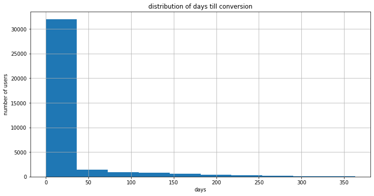

```python
conversion_table['conversion_day'].hist(figsize = (12, 6))
plt.title('distribution of days till conversion')
plt.xlabel('days')
plt.ylabel('number of users')
plt.show()
```

**Reviewer's comment:** Days are too rough units in this case. Please, use minutes instead of it.

**Student's comment:** Recalculated conversion distribution by minute - see graph below for conclusions

```python
# calculate the conversion minute - when a user becomes a buyer
conversion_table['conversion_minute'] = (conversion_table['first_order_date'] - conversion_table['first_session_date']).dt.total_seconds() / 60
conversion_table.head(10)
```

|  | user_id | first_session_date | first_order_date | conversion_day | conversion_minute |
| --- | --- | --- | --- | --- | --- |
| 0 | 313578113262317 | 2017-09-18 22:49:00 | 2018-01-03 21:51:00 | 106 | 154022.0 |
| 1 | 1575281904278712 | 2017-06-03 10:13:00 | 2017-06-03 10:13:00 | 0 | 0.0 |
| 2 | 2429014661409475 | 2017-10-11 17:14:00 | 2017-10-11 18:33:00 | 0 | 79.0 |
| 3 | 2464366381792757 | 2018-01-27 20:10:00 | 2018-01-28 15:54:00 | 0 | 1184.0 |
| 4 | 2551852515556206 | 2017-11-24 10:14:00 | 2017-11-24 10:14:00 | 0 | 0.0 |
| 5 | 3077748354309989 | 2018-03-03 12:08:00 | 2018-03-03 12:33:00 | 0 | 25.0 |
| 6 | 3605148382144603 | 2017-08-15 21:54:00 | 2017-09-21 20:56:00 | 36 | 53222.0 |
| 7 | 3753586865891862 | 2018-03-03 13:47:00 | 2018-03-03 13:50:00 | 0 | 3.0 |
| 8 | 4808417689019433 | 2018-01-09 23:10:00 | 2018-01-09 23:32:00 | 0 | 22.0 |
| 9 | 4992223027560440 | 2018-04-04 13:54:00 | 2018-04-04 13:54:00 | 0 | 0.0 |

```python
print('conversion minute stats')
conversion_table['conversion_minute'].describe()
```

```
conversion minute stats
```

```
count     36522.000000
mean      24340.842205
std       67785.583078
min           0.000000
25%           4.000000
50%          16.000000
75%        2897.500000
max      523144.000000
Name: conversion_minute, dtype: float64
```

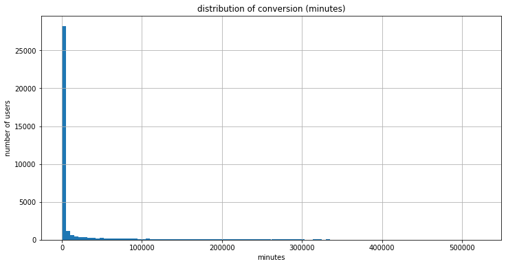

```python
conversion_table['conversion_minute'].hist(figsize = (12, 6), bins = 100)
plt.title('distribution of conversion (minutes)')
plt.xlabel('minutes')
plt.ylabel('number of users')
plt.show()
```

**Student's comment:** Conversion distribution by minute conclusion: 50% of users become buyers in 16 minutes or less, 75% in roughly 2 days or less. Because of the nature of the website, this makes sense, a user will likely come to this website for a specific reason to buy concert tickets. The website may also have a buy now button to make purchasing fast and easy.

**Reviewer's comment v2:** Good! By the way, you cal align those plots side by side. Check this example: https://matplotlib.org/stable/gallery/lines_bars_and_markers/categorical_variables.html#sphx-glr-gallery-lines-bars-and-markers-categorical-variables-py

*How many orders do they make during a given period of time?*

- create necessary columns
- create a series with the number of orders per unique user for each month
- determine average weekly order

```python
orders.head()
```

|  | order_datetime | revenue | user_id |
| --- | --- | --- | --- |
| 0 | 2017-06-01 00:10:00 | 17.00 | 10329302124590727494 |
| 1 | 2017-06-01 00:25:00 | 0.55 | 11627257723692907447 |
| 2 | 2017-06-01 00:27:00 | 0.37 | 17903680561304213844 |
| 3 | 2017-06-01 00:29:00 | 0.55 | 16109239769442553005 |
| 4 | 2017-06-01 07:58:00 | 0.37 | 14200605875248379450 |

```python
# create a column of the order month
orders['order_month'] = orders['order_datetime'].astype('datetime64[M]')
orders.head()
```

|  | order_datetime | revenue | user_id | order_month |
| --- | --- | --- | --- | --- |
| 0 | 2017-06-01 00:10:00 | 17.00 | 10329302124590727494 | 2017-06-01 |
| 1 | 2017-06-01 00:25:00 | 0.55 | 11627257723692907447 | 2017-06-01 |
| 2 | 2017-06-01 00:27:00 | 0.37 | 17903680561304213844 | 2017-06-01 |
| 3 | 2017-06-01 00:29:00 | 0.55 | 16109239769442553005 | 2017-06-01 |
| 4 | 2017-06-01 07:58:00 | 0.37 | 14200605875248379450 | 2017-06-01 |

```python
# create a series to hold the number of orders per unique user for each month
unique_orders = orders.groupby('order_month').agg({'user_id': 'nunique', 'order_datetime': 'count'}).reset_index()
unique_orders.columns = ['order_month', 'num_unique_users', 'total_orders_per_month']
unique_orders.head()
```

|  | order_month | num_unique_users | total_orders_per_month |
| --- | --- | --- | --- |
| 0 | 2017-06-01 | 2023 | 2354 |
| 1 | 2017-07-01 | 1984 | 2363 |
| 2 | 2017-08-01 | 1472 | 1807 |
| 3 | 2017-09-01 | 2750 | 3387 |
| 4 | 2017-10-01 | 4675 | 5679 |

```python
# calculate the average # of orders placed for each month
unique_orders['avg_orders_placed_per_month'] = unique_orders['total_orders_per_month'] / unique_orders['num_unique_users']
unique_orders
```

|  | order_month | num_unique_users | total_orders_per_month | avg_orders_placed_per_month |
| --- | --- | --- | --- | --- |
| 0 | 2017-06-01 | 2023 | 2354 | 1.163618 |
| 1 | 2017-07-01 | 1984 | 2363 | 1.191028 |
| 2 | 2017-08-01 | 1472 | 1807 | 1.227582 |
| 3 | 2017-09-01 | 2750 | 3387 | 1.231636 |
| 4 | 2017-10-01 | 4675 | 5679 | 1.214759 |
| 5 | 2017-11-01 | 4547 | 5659 | 1.244557 |
| 6 | 2017-12-01 | 4942 | 6218 | 1.258195 |
| 7 | 2018-01-01 | 3898 | 4721 | 1.211134 |
| 8 | 2018-02-01 | 4258 | 5281 | 1.240254 |
| 9 | 2018-03-01 | 4181 | 5326 | 1.273858 |
| 10 | 2018-04-01 | 2744 | 3273 | 1.192784 |
| 11 | 2018-05-01 | 3544 | 4346 | 1.226298 |

```python
# calculate the average orders placed per user per month
print('average number of orders placed per user per month:', unique_orders['avg_orders_placed_per_month'].mean().round(2))
```

```
average number of orders placed per user per month: 1.22
```

*What is the average purchase size?*

- calculate the average revenue per order

```python
print('average spent per order:', orders['revenue'].mean().round(2))
```

```
average spent per order: 5.0
```

**Reviewer's comment:** Yes, you are right.

*How much money do they bring? (LTV)*

- LTV (lifetime value) is the customer's lifetime value.
- It's the total amount of money a customer brings to the company on average by making purchases.
- When calculating LTV, analysts usually consider the gross profit from a customer per period.
  - create necessary columns and tables
  - create cohorts based on first session month
  - calculate the revenue per cohort
  - calculate the age of the cohort = difference between the first session and first order
  - calcultae the LTV
  - create a heat map for analysis

```python
# reminder of table contents that might be needed
display(visits.head(2))
display(orders.head(2))
display(conversion_table.head(2))
```

|  | device_type | session_end | source_id | session_start | user_id | session_date | session_week | session_month | session_date_D | session_week_W | session_length_minutes |
| --- | --- | --- | --- | --- | --- | --- | --- | --- | --- | --- | --- |
| 0 | touch | 2017-12-20 17:38:00 | 4 | 2017-12-20 17:20:00 | 16879256277535980062 | 2017-12-20 | 51 | 2017-12-01 | 2017-12-20 | 2017-12-14 | 18.0 |
| 1 | desktop | 2018-02-19 17:21:00 | 2 | 2018-02-19 16:53:00 | 104060357244891740 | 2018-02-19 | 8 | 2018-02-01 | 2018-02-19 | 2018-02-15 | 28.0 |

|  | order_datetime | revenue | user_id | order_month |
| --- | --- | --- | --- | --- |
| 0 | 2017-06-01 00:10:00 | 17.00 | 10329302124590727494 | 2017-06-01 |
| 1 | 2017-06-01 00:25:00 | 0.55 | 11627257723692907447 | 2017-06-01 |

|  | user_id | first_session_date | first_order_date | conversion_day | conversion_minute |
| --- | --- | --- | --- | --- | --- |
| 0 | 313578113262317 | 2017-09-18 22:49:00 | 2018-01-03 21:51:00 | 106 | 154022.0 |
| 1 | 1575281904278712 | 2017-06-03 10:13:00 | 2017-06-03 10:13:00 | 0 | 0.0 |

```python
display(orders.head(2))
display(costs.head(2))
```

|  | order_datetime | revenue | user_id | order_month |
| --- | --- | --- | --- | --- |
| 0 | 2017-06-01 00:10:00 | 17.00 | 10329302124590727494 | 2017-06-01 |
| 1 | 2017-06-01 00:25:00 | 0.55 | 11627257723692907447 | 2017-06-01 |

|  | source_id | ad_datetime | ad_cost |
| --- | --- | --- | --- |
| 0 | 1 | 2017-06-01 | 75.20 |
| 1 | 1 | 2017-06-02 | 62.25 |

```python
# create new columns & confirm datatypes were changed
conversion_table[['first_session_month', 'first_order_month']] = conversion_table[['first_session_date', 'first_order_date']].astype('datetime64[M]')
display(conversion_table.head())
display(conversion_table.info())
```

|  | user_id | first_session_date | first_order_date | conversion_day | conversion_minute | first_session_month | first_order_month |
| --- | --- | --- | --- | --- | --- | --- | --- |
| 0 | 313578113262317 | 2017-09-18 22:49:00 | 2018-01-03 21:51:00 | 106 | 154022.0 | 2017-09-01 | 2018-01-01 |
| 1 | 1575281904278712 | 2017-06-03 10:13:00 | 2017-06-03 10:13:00 | 0 | 0.0 | 2017-06-01 | 2017-06-01 |
| 2 | 2429014661409475 | 2017-10-11 17:14:00 | 2017-10-11 18:33:00 | 0 | 79.0 | 2017-10-01 | 2017-10-01 |
| 3 | 2464366381792757 | 2018-01-27 20:10:00 | 2018-01-28 15:54:00 | 0 | 1184.0 | 2018-01-01 | 2018-01-01 |
| 4 | 2551852515556206 | 2017-11-24 10:14:00 | 2017-11-24 10:14:00 | 0 | 0.0 | 2017-11-01 | 2017-11-01 |

```
<class 'pandas.core.frame.DataFrame'>
Int64Index: 36522 entries, 0 to 36521
Data columns (total 7 columns):
user_id                36522 non-null uint64
first_session_date     36522 non-null datetime64[ns]
first_order_date       36522 non-null datetime64[ns]
conversion_day         36522 non-null int64
conversion_minute      36522 non-null float64
first_session_month    36522 non-null datetime64[ns]
first_order_month      36522 non-null datetime64[ns]
dtypes: datetime64[ns](4), float64(1), int64(1), uint64(1)
memory usage: 2.2 MB
```

```
None
```

```python
# create a table with needed information
first_session_info = conversion_table[['user_id', 'first_session_month']]
display(first_session_info.head())
```

|  | user_id | first_session_month |
| --- | --- | --- |
| 0 | 313578113262317 | 2017-09-01 |
| 1 | 1575281904278712 | 2017-06-01 |
| 2 | 2429014661409475 | 2017-10-01 |
| 3 | 2464366381792757 | 2018-01-01 |
| 4 | 2551852515556206 | 2017-11-01 |

**Student's comment:** found a typo in my code - removed this bc it is inaccurate and unused in these calculations.

**Reviewer's comment v2:** 👍

```python
# found a typo in my code - removed this bc it is inaccurate and unused in these calculations

# # create a column of the first order month in the orders table
# orders['first_order_month'] = orders['order_datetime'].astype('datetime64[M]')
# display(orders.head())
```

```python
# merge the two tables
firsts_info = orders.merge(first_session_info, on = 'user_id')
display(firsts_info.head())
firsts_info.info()
```

|  | order_datetime | revenue | user_id | order_month | first_session_month |
| --- | --- | --- | --- | --- | --- |
| 0 | 2017-06-01 00:10:00 | 17.00 | 10329302124590727494 | 2017-06-01 | 2017-06-01 |
| 1 | 2017-06-01 00:25:00 | 0.55 | 11627257723692907447 | 2017-06-01 | 2017-06-01 |
| 2 | 2017-06-01 00:27:00 | 0.37 | 17903680561304213844 | 2017-06-01 | 2017-06-01 |
| 3 | 2017-06-01 00:29:00 | 0.55 | 16109239769442553005 | 2017-06-01 | 2017-06-01 |
| 4 | 2017-06-01 07:58:00 | 0.37 | 14200605875248379450 | 2017-06-01 | 2017-06-01 |

```
<class 'pandas.core.frame.DataFrame'>
Int64Index: 50414 entries, 0 to 50413
Data columns (total 5 columns):
order_datetime         50414 non-null datetime64[ns]
revenue                50414 non-null float64
user_id                50414 non-null uint64
order_month            50414 non-null datetime64[ns]
first_session_month    50414 non-null datetime64[ns]
dtypes: datetime64[ns](3), float64(1), uint64(1)
memory usage: 2.3 MB
```

```python
# create a new series to calculate the number of users per cohort
cohort_sizes = firsts_info.groupby('first_session_month').agg({'user_id': 'nunique'}).reset_index()
cohort_sizes.columns = ['first_session_month', 'cohort_size']
cohort_sizes
```

|  | first_session_month | cohort_size |
| --- | --- | --- |
| 0 | 2017-06-01 | 2923 |
| 1 | 2017-07-01 | 2458 |
| 2 | 2017-08-01 | 1721 |
| 3 | 2017-09-01 | 3058 |
| 4 | 2017-10-01 | 4678 |
| 5 | 2017-11-01 | 4262 |
| 6 | 2017-12-01 | 4074 |
| 7 | 2018-01-01 | 3119 |
| 8 | 2018-02-01 | 3186 |
| 9 | 2018-03-01 | 2838 |
| 10 | 2018-04-01 | 1890 |
| 11 | 2018-05-01 | 2315 |

```python
# create a new series to calculate the cohort revenues
cohort_revenues = firsts_info.groupby(['first_session_month', 'order_month']).agg({'revenue': ['sum', 'count']}).reset_index()
cohort_revenues.head()
```

|  | first_session_month | order_month | revenue sum | revenue count |
| --- | --- | --- | --- | --- |
| 0 | 2017-06-01 | 2017-06-01 | 9557.49 | 2354 |
| 1 | 2017-06-01 | 2017-07-01 | 2664.58 | 387 |
| 2 | 2017-06-01 | 2017-08-01 | 1464.69 | 273 |
| 3 | 2017-06-01 | 2017-09-01 | 3882.09 | 442 |
| 4 | 2017-06-01 | 2017-10-01 | 3940.59 | 516 |

```python
# create the cohort age column and rename columns
cohort_revenues['age'] = ((cohort_revenues['order_month'] - cohort_revenues['first_session_month']) / np.timedelta64(1, 'M')).round().astype('int')
cohort_revenues.columns = ['first_session_month', 'order_month', 'revenue', 'num_orders', 'cohort_age_month']
cohort_revenues.head()
```

|  | first_session_month | order_month | revenue | num_orders | cohort_age_month |
| --- | --- | --- | --- | --- | --- |
| 0 | 2017-06-01 | 2017-06-01 | 9557.49 | 2354 | 0 |
| 1 | 2017-06-01 | 2017-07-01 | 2664.58 | 387 | 1 |
| 2 | 2017-06-01 | 2017-08-01 | 1464.69 | 273 | 2 |
| 3 | 2017-06-01 | 2017-09-01 | 3882.09 | 442 | 3 |
| 4 | 2017-06-01 | 2017-10-01 | 3940.59 | 516 | 4 |

```python
# merge the cohort size and revenue/age tables
cohort_report = pd.merge(cohort_sizes, cohort_revenues, on = 'first_session_month')
display(cohort_report.head())
```

|  | first_session_month | cohort_size | order_month | revenue | num_orders | cohort_age_month |
| --- | --- | --- | --- | --- | --- | --- |
| 0 | 2017-06-01 | 2923 | 2017-06-01 | 9557.49 | 2354 | 0 |
| 1 | 2017-06-01 | 2923 | 2017-07-01 | 2664.58 | 387 | 1 |
| 2 | 2017-06-01 | 2923 | 2017-08-01 | 1464.69 | 273 | 2 |
| 3 | 2017-06-01 | 2923 | 2017-09-01 | 3882.09 | 442 | 3 |
| 4 | 2017-06-01 | 2923 | 2017-10-01 | 3940.59 | 516 | 4 |

```python
# calculate the LTV
cohort_report['ltv'] = cohort_report['revenue'] / cohort_report['cohort_size']
cohort_report.head()
```

|  | first_session_month | cohort_size | order_month | revenue | num_orders | cohort_age_month | ltv |
| --- | --- | --- | --- | --- | --- | --- | --- |
| 0 | 2017-06-01 | 2923 | 2017-06-01 | 9557.49 | 2354 | 0 | 3.269754 |
| 1 | 2017-06-01 | 2923 | 2017-07-01 | 2664.58 | 387 | 1 | 0.911591 |
| 2 | 2017-06-01 | 2923 | 2017-08-01 | 1464.69 | 273 | 2 | 0.501091 |
| 3 | 2017-06-01 | 2923 | 2017-09-01 | 3882.09 | 442 | 3 | 1.328118 |
| 4 | 2017-06-01 | 2923 | 2017-10-01 | 3940.59 | 516 | 4 | 1.348132 |

| cohort_age_month first_session_month | 0 | 1 | 2 | 3 | 4 | 5 | 6 | 7 | 8 | 9 | 10 | 11 |
| --- | --- | --- | --- | --- | --- | --- | --- | --- | --- | --- | --- | --- |
| 2017-06-01 | 3.269754 | 4.18134 | 4.68244 | 6.01055 | 7.35869 | 8.32498 | 9.51894 | 10.2958 | 11.0888 | 12.2799 | 13.034 | 13.6935 |
| 2017-07-01 | 4.017449 | 4.4484 | 4.89954 | 5.29944 | 5.64403 | 5.96871 | 6.20793 | 6.52132 | 6.81608 | 7.05653 | 7.24659 |  |
| 2017-08-01 | 3.622783 | 4.20228 | 4.78413 | 5.33393 | 5.80461 | 6.11425 | 6.39702 | 7.12116 | 7.60381 | 7.82212 |  |  |
| 2017-09-01 | 4.040942 | 5.25104 | 5.94124 | 9.35489 | 9.77623 | 10.4008 | 10.717 | 10.8777 | 11.0146 |  |  |  |
| 2017-10-01 | 3.925250 | 4.73966 | 5.02334 | 5.24951 | 5.47257 | 5.69108 | 5.81483 | 5.95504 |  |  |  |  |
| 2017-11-01 | 3.878881 | 4.50478 | 4.81985 | 5.14119 | 5.40134 | 5.56737 | 5.73128 |  |  |  |  |  |
| 2017-12-01 | 4.137703 | 4.56456 | 5.59507 | 6.85276 | 7.21054 | 7.64797 |  |  |  |  |  |  |
| 2018-01-01 | 3.397567 | 4.02331 | 4.39675 | 4.49482 | 4.66394 |  |  |  |  |  |  |  |
| 2018-02-01 | 3.613506 | 4.23637 | 4.44453 | 4.72734 |  |  |  |  |  |  |  |  |
| 2018-03-01 | 4.232343 | 4.57907 | 4.85206 |  |  |  |  |  |  |  |  |  |
| 2018-04-01 | 4.255989 | 5.22886 |  |  |  |  |  |  |  |  |  |  |
| 2018-05-01 | 4.478665 |  |  |  |  |  |  |  |  |  |  |  |

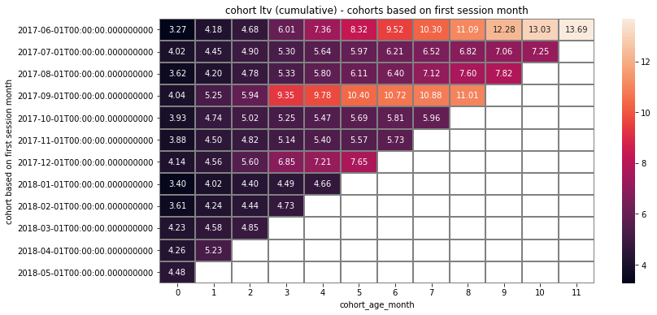

```python
# create an LTV table
ltv_table = cohort_report.pivot_table(index = 'first_session_month', columns = 'cohort_age_month', values = 'ltv', aggfunc = 'mean').cumsum(axis = 1)
display(ltv_table.fillna(''))

plt.figure(figsize=(12, 6))
sns.heatmap(ltv_table, annot=True, fmt='.2f', linewidths=1, linecolor='gray')
plt.title('cohort ltv (cumulative) - cohorts based on first session month')
plt.ylabel('cohort based on first session month')
plt.show()
```

**Student's comment:** I have recalculated this information below the troubleshooting. The above graph is designed on cohorts that are based on the first session month, however it appears that this is an incorrect analysis for this project, so I redid it with the cohorts based on the first order month. I am not including a conclusion here, I will include it in the graph to follow.

**Reviewer's comment:** Please, check your calculations. It's impossible that the youngest cohort (05-2018) has already had two-month history.

**Student's comment:** There is an extra line of code in the orders dataset that is causing this, I am including my troubleshooting to find this below.

```python
# working dataset
# orders.tail(3)
```

Output:

```
order_datetime  revenue user_id order_month first_order_month
```

50412 2018-05-31 23:54:00 0.30 1786462140797698849 2018-05-01 2018-05-01

50413 2018-05-31 23:56:00 3.67 3993697860786194247 2018-05-01 2018-05-01

50414 2018-06-01 00:02:00 3.42 83872787173869366 2018-06-01 2018-06-01 <--------

```python
# value counts of order month dataset - shows there is a single order in the month of June 2018
# orders['order_month'].value_counts(dropna = False)
```

Output:

2017-12-01 6218

2017-10-01 5679

2017-11-01 5659

2018-03-01 5326

2018-02-01 5281

2018-01-01 4721

2018-05-01 4346

2017-09-01 3387

2018-04-01 3273

2017-07-01 2363

2017-06-01 2354

2017-08-01 1807

2018-06-01 1 <--------

Name: order_month, dtype: int64

```python
# # original data set (pre modifications/changes) confirms this single order in June 2018
# orders_orig.tail(3)
```

Output:

```
    Buy Ts            Revenue            Uid
```

50412 2018-05-31 23:54:00 0.30 1786462140797698849

50413 2018-05-31 23:56:00 3.67 3993697860786194247

50414 2018-06-01 00:02:00 3.42 83872787173869366 <--------

```python
# # confirm that the order was made by the May 2018 and not June 2018 (non existant) cohort
# may2018_cohort_query = cohort_report.query('first_session_month == "2018-05-01"')
# display(may2018_cohort_query)
# june2018_cohort_query = cohort_report.query('first_session_month == "2018-06-01"')
# display(june2018_cohort_query)
```

Output:

first_session_month cohort_size order_month revenue num_orders cohort_age_month ltv

77 2018-05-01 2316 2018-05-01 10368.11 2476 0 4.476731

78 2018-05-01 2316 2018-06-01 3.42 1 1 0.001477

first_session_month cohort_size order_month revenue num_orders cohort_age_month ltv <--------

**Student's comment:** End of troubleshooting - I am going to delete this extra row in section 3 (data preprocessing) of this notebook.

**Reviewer's comment v2:** Excellent, thank you for explanation.

**Student's comment:** Recalculation of LTV with cohorts based on the first purchase month vs the first session month.

**Reviewer's comment v2:** Both metrics are correct :) Great that you noticed the difference between them. In general, the second type of LTV is more common.

```python
orders.head(2)
```

|  | order_datetime | revenue | user_id | order_month |
| --- | --- | --- | --- | --- |
| 0 | 2017-06-01 00:10:00 | 17.00 | 10329302124590727494 | 2017-06-01 |
| 1 | 2017-06-01 00:25:00 | 0.55 | 11627257723692907447 | 2017-06-01 |

```python
# create a series with the first order month, rename the columns
first_orders = orders.groupby('user_id').agg({'order_month': 'min'}).reset_index()
first_orders.columns = ['user_id', 'first_order_month']
first_orders.head()
```

|  | user_id | first_order_month |
| --- | --- | --- |
| 0 | 313578113262317 | 2018-01-01 |
| 1 | 1575281904278712 | 2017-06-01 |
| 2 | 2429014661409475 | 2017-10-01 |
| 3 | 2464366381792757 | 2018-01-01 |
| 4 | 2551852515556206 | 2017-11-01 |

```python
# create a series to calculate the number of buyers in the cohort ie the cohort size
cohort_buyers = first_orders.groupby('first_order_month').agg({'user_id': 'nunique'}).reset_index()
cohort_buyers.columns = ['first_order_month', 'cohort_buyers']
cohort_buyers.head()
```

|  | first_order_month | cohort_buyers |
| --- | --- | --- |
| 0 | 2017-06-01 | 2023 |
| 1 | 2017-07-01 | 1923 |
| 2 | 2017-08-01 | 1370 |
| 3 | 2017-09-01 | 2581 |
| 4 | 2017-10-01 | 4340 |

```python
# combine tables to add the cohort to the orders table
cohort_orders = pd.merge(orders, first_orders, on = 'user_id')
cohort_orders.head()
```

|  | order_datetime | revenue | user_id | order_month | first_order_month |
| --- | --- | --- | --- | --- | --- |
| 0 | 2017-06-01 00:10:00 | 17.00 | 10329302124590727494 | 2017-06-01 | 2017-06-01 |
| 1 | 2017-06-01 00:25:00 | 0.55 | 11627257723692907447 | 2017-06-01 | 2017-06-01 |
| 2 | 2017-06-01 00:27:00 | 0.37 | 17903680561304213844 | 2017-06-01 | 2017-06-01 |
| 3 | 2017-06-01 00:29:00 | 0.55 | 16109239769442553005 | 2017-06-01 | 2017-06-01 |
| 4 | 2017-06-01 07:58:00 | 0.37 | 14200605875248379450 | 2017-06-01 | 2017-06-01 |

```python
# create a series to calculate the revenue of the cohorts based on first month order
cohort_revs = cohort_orders.groupby(['first_order_month', 'order_month']).agg({'revenue': 'sum'}).reset_index()
cohort_revs.columns = ['first_order_month', 'order_month', 'cohort_revenue']
cohort_revs.head()
```

|  | first_order_month | order_month | cohort_revenue |
| --- | --- | --- | --- |
| 0 | 2017-06-01 | 2017-06-01 | 9557.49 |
| 1 | 2017-06-01 | 2017-07-01 | 981.82 |
| 2 | 2017-06-01 | 2017-08-01 | 885.34 |
| 3 | 2017-06-01 | 2017-09-01 | 1931.30 |
| 4 | 2017-06-01 | 2017-10-01 | 2068.58 |

```python
# join tables to create a table to calculate the ltv
ltv_report = pd.merge(cohort_buyers, cohort_revs, on = 'first_order_month')
ltv_report.head()
```

|  | first_order_month | cohort_buyers | order_month | cohort_revenue |
| --- | --- | --- | --- | --- |
| 0 | 2017-06-01 | 2023 | 2017-06-01 | 9557.49 |
| 1 | 2017-06-01 | 2023 | 2017-07-01 | 981.82 |
| 2 | 2017-06-01 | 2023 | 2017-08-01 | 885.34 |
| 3 | 2017-06-01 | 2023 | 2017-09-01 | 1931.30 |
| 4 | 2017-06-01 | 2023 | 2017-10-01 | 2068.58 |

```python
# create a cohort age column
ltv_report['age'] = (ltv_report['order_month'] - ltv_report['first_order_month']) / np.timedelta64(1, 'M')
ltv_report['age'] = ltv_report['age'].round().astype('int')
# calculate the ltv
ltv_report['ltv'] = ltv_report['cohort_revenue'] / ltv_report['cohort_buyers']
ltv_report.head()
```

|  | first_order_month | cohort_buyers | order_month | cohort_revenue | age | ltv |
| --- | --- | --- | --- | --- | --- | --- |
| 0 | 2017-06-01 | 2023 | 2017-06-01 | 9557.49 | 0 | 4.724414 |
| 1 | 2017-06-01 | 2023 | 2017-07-01 | 981.82 | 1 | 0.485329 |
| 2 | 2017-06-01 | 2023 | 2017-08-01 | 885.34 | 2 | 0.437637 |
| 3 | 2017-06-01 | 2023 | 2017-09-01 | 1931.30 | 3 | 0.954671 |
| 4 | 2017-06-01 | 2023 | 2017-10-01 | 2068.58 | 4 | 1.022531 |

| age first_order_month | 0 | 1 | 2 | 3 | 4 | 5 | 6 | 7 | 8 | 9 | 10 | 11 |
| --- | --- | --- | --- | --- | --- | --- | --- | --- | --- | --- | --- | --- |
| 2017-06-01 | 4.724414 | 5.20974 | 5.64738 | 6.60205 | 7.62458 | 8.36008 | 9.31052 | 9.89212 | 10.4453 | 11.0511 | 11.6224 | 11.8792 |
| 2017-07-01 | 6.010218 | 6.34543 | 6.96896 | 7.32794 | 7.50473 | 7.66077 | 7.78098 | 7.9228 | 8.08404 | 8.23118 | 8.38685 |  |
| 2017-08-01 | 5.276518 | 5.74851 | 6.20699 | 6.59827 | 7.09232 | 7.37586 | 7.58653 | 7.99153 | 8.28374 | 8.47172 |  |  |
| 2017-09-01 | 5.644529 | 6.76212 | 7.28305 | 11.2588 | 11.6594 | 12.3065 | 13.0081 | 13.2512 | 13.4352 |  |  |  |
| 2017-10-01 | 5.003733 | 5.5395 | 5.73089 | 5.88803 | 6.03959 | 6.15996 | 6.24477 | 6.36024 |  |  |  |  |
| 2017-11-01 | 5.154683 | 5.55392 | 5.75347 | 6.07842 | 6.22644 | 6.28032 | 6.39524 |  |  |  |  |  |
| 2017-12-01 | 4.738191 | 4.99856 | 5.92366 | 6.98894 | 7.30187 | 7.63991 |  |  |  |  |  |  |
| 2018-01-01 | 4.135636 | 4.43039 | 4.73468 | 4.87745 | 4.94015 |  |  |  |  |  |  |  |
| 2018-02-01 | 4.156987 | 4.43526 | 4.51378 | 4.58792 |  |  |  |  |  |  |  |  |
| 2018-03-01 | 4.838803 | 5.13969 | 5.45525 |  |  |  |  |  |  |  |  |  |
| 2018-04-01 | 4.657597 | 5.1892 |  |  |  |  |  |  |  |  |  |  |
| 2018-05-01 | 4.660562 |  |  |  |  |  |  |  |  |  |  |  |

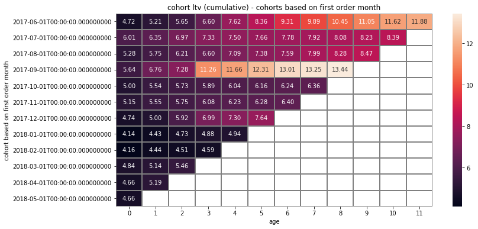

```python
# create a pivot table of the cumulated ltv and graph with a heat map
ltv_table = ltv_report.pivot_table(index = 'first_order_month', columns = 'age', values = 'ltv', aggfunc = 'mean').cumsum(axis = 1)
display(ltv_table.fillna(''))

plt.figure(figsize=(12, 6))
sns.heatmap(ltv_table, annot=True, fmt='.2f', linewidths=1, linecolor='gray')
plt.title('cohort ltv (cumulative) - cohorts based on first order month')
plt.ylabel('cohort based on first order month')
plt.show()
```

**Student's comment:** Conclusion: Recalculation of LTV with cohorts based on the first purchase month vs the first session month. Based on this data set the 06-2017 and 09-2017 cohorts have brought the greatest lifetime value, however this happened much quickly for the 09-2017 cohort, which doubled after 3 months (in December 2017). 06-2017 cohort took about 6 months. All other cohorts are increasing at a slower rate. In general there is an increase in rates, so far.

# 4b Sales Data Analysis Conclusions

*When do people start buying? (In KPI analysis, we're usually interested in knowing the time that elapses between registration and conversion — when the user becomes a customer. For example, if registration and the first purchase occur on the same day, the user might fall into category Conversion 0d. If the first purchase happens the next day, it will be Conversion 1d. You can use any approach that lets you compare the conversions of different cohorts, so that you can determine which cohort, or marketing channel, is most effective.)*

- Actions performed
  - created series to get first session and order information
  - combined tables
  - calculated the conversion day - when a user becamea buyer
  - evaluated the stats and made a histogram
- Conclusions
  - 50% of conversions (user to a buyer) happen by day 0 of a users first session date
  - 75% of conversions happen by day 2
  - This suggests that most users become buyers soon after their first visit

*How many orders do they make during a given period of time?*

- Actions performed
  - created necessary columns
  - created a series with the number of orders per unique user for each month
  - determined average weekly orders
- Conclusions
  - 1.21 average number of orders placed per user per month

*What is the average purchase size?*

- Actions performed
  - calculated the average revenue per order
- Conclusions
  - 5 dollars is the average purchase size per order

*How much money do they bring? (LTV)*

**Reviewer's comment:** Excellent, time for marketing analysis 💪

# 4c Marketing Data Analysis

*Examine the marketing*

- Marketing
  - How much money was spent? Overall/per source/over time
    - calculate
      - overall costs
      - cost per ad source
      - cost over time
  - How much did customer acquisition from each of the sources cost?
  - How worthwhile where the investments? (ROI)
  - Plot graphs to display how these metrics differ for various devices and ad sources and how they change in time.

*How much money was spent?*

- Overall
- Per ad source
- Over time

*Overall costs*

```python
# calculate total costs (overall costs)
print('overall money spent:', costs['ad_cost'].sum())
```

```
overall money spent: 329131.62
```

*Cost per ad source*

```python
# determine costs per ad source
# create a new series
cost_per_source = costs.groupby('source_id').agg({'ad_cost': ['sum', 'mean']}).reset_index()
cost_per_source.columns = ['source_id', 'cost_per_source', 'avg_cost_per_source']
cost_per_source
```

|  | source_id | cost_per_source | avg_cost_per_source |
| --- | --- | --- | --- |
| 0 | 1 | 20833.27 | 57.391928 |
| 1 | 2 | 42806.04 | 117.922975 |
| 2 | 3 | 141321.63 | 389.315785 |
| 3 | 4 | 61073.60 | 168.246832 |
| 4 | 5 | 51757.10 | 142.189835 |
| 5 | 9 | 5517.49 | 15.199697 |
| 6 | 10 | 5822.49 | 16.039917 |

```python
print('cost per ad stats')
cost_per_source['cost_per_source'].describe()
```

```
cost per ad stats
```

```
count         7.000000
mean      47018.802857
std       46967.961870
min        5517.490000
25%       13327.880000
50%       42806.040000
75%       56415.350000
max      141321.630000
Name: cost_per_source, dtype: float64
```

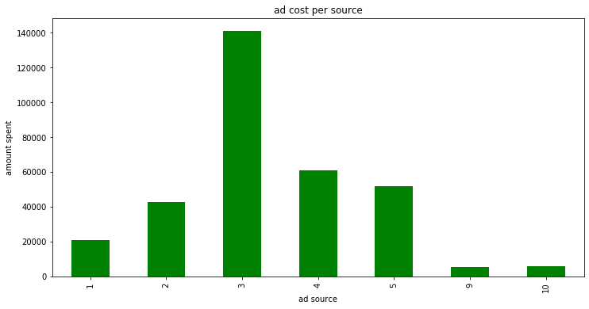

```python
# graph the costs per ad source
cost_per_source_graph = cost_per_source['cost_per_source'].plot(kind = 'bar', figsize = (12, 6), color = 'green')
plt.title('ad cost per source')
plt.xlabel('ad source')
plt.ylabel('amount spent')
cost_per_source_graph.set_xticklabels(cost_per_source['source_id'])
plt.show()
```

**Student's comment:** Conclusion: ad cost per source: - There are 7 different ad sources in this data set - yearly cost ranges from 5517 - 141321 dollars - ad source 3 costs the most, followed by 4, 5, and 2

**Reviewer's comment:** Good, all calculations aboove are correct.

*Costs over time*

```python
# create a new column for ad month
costs['ad_month'] = costs['ad_datetime'].dt.month
costs['ad_month'] = costs['ad_datetime'].astype('datetime64[M]')

costs.head()
```

|  | source_id | ad_datetime | ad_cost | ad_month |
| --- | --- | --- | --- | --- |
| 0 | 1 | 2017-06-01 | 75.20 | 2017-06-01 |
| 1 | 1 | 2017-06-02 | 62.25 | 2017-06-01 |
| 2 | 1 | 2017-06-03 | 36.53 | 2017-06-01 |
| 3 | 1 | 2017-06-04 | 55.00 | 2017-06-01 |
| 4 | 1 | 2017-06-05 | 57.08 | 2017-06-01 |

```python
# group costs by ad month
costs_per_month = costs.groupby(['ad_month']).agg({'ad_cost': ['sum', 'mean']}).reset_index()
costs_per_month.columns = ['ad_month', 'costs_per_month', 'avg_costs_per_month']
costs_per_month
```

|  | ad_month | costs_per_month | avg_costs_per_month |
| --- | --- | --- | --- |
| 0 | 2017-06-01 | 18015.00 | 85.785714 |
| 1 | 2017-07-01 | 18240.59 | 84.058018 |
| 2 | 2017-08-01 | 14790.54 | 68.159171 |
| 3 | 2017-09-01 | 24368.91 | 116.042429 |
| 4 | 2017-10-01 | 36322.88 | 167.386544 |
| 5 | 2017-11-01 | 37907.88 | 180.513714 |
| 6 | 2017-12-01 | 38315.35 | 176.568433 |
| 7 | 2018-01-01 | 33518.52 | 154.463226 |
| 8 | 2018-02-01 | 32723.03 | 166.954235 |
| 9 | 2018-03-01 | 30415.27 | 144.148199 |
| 10 | 2018-04-01 | 22289.38 | 109.799901 |
| 11 | 2018-05-01 | 22224.27 | 102.415991 |

```python
costs_per_month['costs_per_month'].describe()
```

```
count       12.000000
mean     27427.635000
std       8405.071207
min      14790.540000
25%      21228.350000
50%      27392.090000
75%      34219.610000
max      38315.350000
Name: costs_per_month, dtype: float64
```

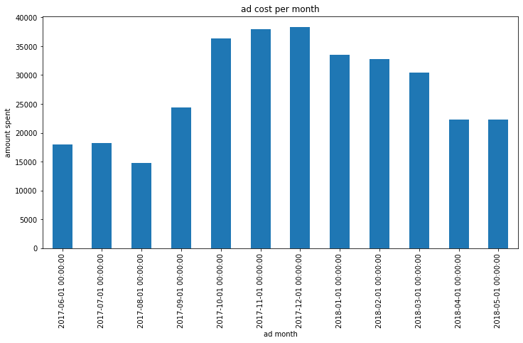

```python
cost_per_month_graph = costs_per_month['costs_per_month'].plot(kind = 'bar', figsize = (12, 6))
plt.title('ad cost per month')
plt.xlabel('ad month')
plt.ylabel('amount spent')
cost_per_month_graph.set_xticklabels(costs_per_month['ad_month'])
plt.show()
```

**Student's comment:** Conclusion: ad cost per month: - the least amount spent on ads was in August 2017: 14790, the most in December 2017: 38315 - ad costs appear to be low in the summer months and high in the fall through winter, the highest in October, November, and December 2017, followed by January, February, and March 2018

**Reviewer's comment:** Pay attention, that you've mixed months from the different years.

**Student's comment:** updated the information to include more info for the ad month.

**Reviewer's comment v2:** Good job!

*How much did customer acquisition from each of the sources cost?*

- calculate the CAC

**Student's comment:** V3: commented out incorrect CAC calculations.

```python
# visits.head(2)
```

```python
# cost_per_source.head(2)
```

```python
# # create a series of source_id and user_id
# users_per_source = visits.groupby('source_id').agg({'user_id': 'nunique'}).reset_index()
# users_per_source.columns = ['source_id', 'num_unique_users_per_source']
# users_per_source
```

```python
# ltv_report.head(2)
```

**Reviewer's comment:** Please, pay attention, that CAC should be based on buyers, not visitors.

**Reviewer's comment v2:** Okay, but comment out outdated CAC code, please.

```python
# # join the tables
# cac_report = pd.merge(cost_per_source, users_per_source, on = 'source_id')
# cac_report
```

```python
# # calculate cac
# cac_report['cac'] = cac_report['cost_per_source'] / cac_report['num_unique_users_per_source']
# cac_report
```

```python
# cac_report_graph = cac_report['cac'].plot(kind = 'bar', figsize = (12, 6), color = 'orange')
# plt.title('ad cost per customer acquisitoin')
# plt.xlabel('ad source')
# plt.ylabel('cost per acquisition')
# cac_report_graph.set_xticklabels(cac_report['source_id'])
# plt.show()
```

**Student's comment:** see updated table below

```python
# print('cac stats')
# print(cac_report['cac'].describe())
# print('')
# # calculate the revenue from the first session month for each cohort
# cohort_first_month_revenue = cohort_report.groupby('first_session_month').agg({'ltv':'sum'}).reset_index()
# cohort_first_month_revenue.columns = ['first_session_month', 'first_month_revenue']
# print('first session month revenue per cohort')
# print(cohort_first_month_revenue.describe())
# print('')
# print(cohort_first_month_revenue)
```

**Student's comment:** Recalculated CAC based on buyers vs users

```python
# orders.head(2)
```

```python
# visits.head(2)
```

```python
visits_orders = pd.merge(visits, orders, on = 'user_id')
visits_orders.head(2)
```

|  | device_type | session_end | source_id | session_start | user_id | session_date | session_week | session_month | session_date_D | session_week_W | session_length_minutes | order_datetime | revenue | order_month |
| --- | --- | --- | --- | --- | --- | --- | --- | --- | --- | --- | --- | --- | --- | --- |
| 0 | desktop | 2018-05-20 11:23:00 | 9 | 2018-05-20 10:59:00 | 16174680259334210214 | 2018-05-20 | 20 | 2018-05-01 | 2018-05-20 | 2018-05-17 | 24.0 | 2018-03-09 20:25:00 | 2.33 | 2018-03-01 |
| 1 | desktop | 2018-03-09 20:33:00 | 4 | 2018-03-09 20:05:00 | 16174680259334210214 | 2018-03-09 | 10 | 2018-03-01 | 2018-03-09 | 2018-03-08 | 28.0 | 2018-03-09 20:25:00 | 2.33 | 2018-03-01 |

**Reviewer's comment v2:** Incorrect merge operation. Pay attention, that one user could have different sources. Thus, in the case of direct merging you've got all possible combinations of uid - source_id in your result table. Check table size before and after the merge, adn you will see it. So, here you need to select only the first source for every visitor and join only this necessary series to the orders table.

**Student's comment:** I see what you are talking about and how it has bloated my results

```python
# v3 examine dataframe info as suggested by reviewer
display(visits.info())
display(orders.info())
display(visits_orders.info())
```

```
<class 'pandas.core.frame.DataFrame'>
RangeIndex: 359400 entries, 0 to 359399
Data columns (total 11 columns):
device_type               359400 non-null object
session_end               359400 non-null datetime64[ns]
source_id                 359400 non-null int64
session_start             359400 non-null datetime64[ns]
user_id                   359400 non-null uint64
session_date              359400 non-null datetime64[ns]
session_week              359400 non-null int64
session_month             359400 non-null datetime64[ns]
session_date_D            359400 non-null datetime64[ns]
session_week_W            359400 non-null datetime64[ns]
session_length_minutes    359400 non-null float64
dtypes: datetime64[ns](6), float64(1), int64(2), object(1), uint64(1)
memory usage: 30.2+ MB
```

```
None
```

```
<class 'pandas.core.frame.DataFrame'>
Int64Index: 50414 entries, 0 to 50413
Data columns (total 4 columns):
order_datetime    50414 non-null datetime64[ns]
revenue           50414 non-null float64
user_id           50414 non-null uint64
order_month       50414 non-null datetime64[ns]
dtypes: datetime64[ns](2), float64(1), uint64(1)
memory usage: 1.9 MB
```

```
None
```

```
<class 'pandas.core.frame.DataFrame'>
Int64Index: 761806 entries, 0 to 761805
Data columns (total 14 columns):
device_type               761806 non-null object
session_end               761806 non-null datetime64[ns]
source_id                 761806 non-null int64
session_start             761806 non-null datetime64[ns]
user_id                   761806 non-null uint64
session_date              761806 non-null datetime64[ns]
session_week              761806 non-null int64
session_month             761806 non-null datetime64[ns]
session_date_D            761806 non-null datetime64[ns]
session_week_W            761806 non-null datetime64[ns]
session_length_minutes    761806 non-null float64
order_datetime            761806 non-null datetime64[ns]
revenue                   761806 non-null float64
order_month               761806 non-null datetime64[ns]
dtypes: datetime64[ns](8), float64(2), int64(2), object(1), uint64(1)
memory usage: 87.2+ MB
```

```
None
```

**Student's comment:** V3 Recalculated CAC based on buyers and a single source id per user

```python
# v3 * create a table that finds the first session date of a user
minimum_session_date = visits.loc[visits.groupby('user_id').session_start.idxmin()].reset_index()
minimum_session_date.head()
```

|  | index | device_type | session_end | source_id | session_start | user_id | session_date | session_week | session_month | session_date_D | session_week_W | session_length_minutes |
| --- | --- | --- | --- | --- | --- | --- | --- | --- | --- | --- | --- | --- |
| 0 | 196543 | touch | 2018-03-01 17:33:00 | 3 | 2018-03-01 17:27:00 | 11863502262781 | 2018-03-01 | 9 | 2018-03-01 | 2018-03-01 | 2018-03-01 | 6.0 |
| 1 | 257333 | touch | 2018-02-06 15:57:00 | 2 | 2018-02-06 15:55:00 | 49537067089222 | 2018-02-06 | 6 | 2018-02-01 | 2018-02-06 | 2018-02-01 | 2.0 |
| 2 | 173818 | desktop | 2017-06-07 18:48:00 | 3 | 2017-06-07 18:47:00 | 297729379853735 | 2017-06-07 | 23 | 2017-06-01 | 2017-06-07 | 2017-06-01 | 1.0 |
| 3 | 173142 | desktop | 2017-09-18 23:07:00 | 2 | 2017-09-18 22:49:00 | 313578113262317 | 2017-09-18 | 38 | 2017-09-01 | 2017-09-18 | 2017-09-14 | 18.0 |
| 4 | 34588 | desktop | 2017-09-30 14:38:00 | 5 | 2017-09-30 14:29:00 | 325320750514679 | 2017-09-30 | 39 | 2017-09-01 | 2017-09-30 | 2017-09-28 | 9.0 |

```python
# v3 * create a df with desired info
session_date_min = minimum_session_date[['source_id', 'user_id', 'session_start']]
session_date_min.head()
```

|  | source_id | user_id | session_start |
| --- | --- | --- | --- |
| 0 | 3 | 11863502262781 | 2018-03-01 17:27:00 |
| 1 | 2 | 49537067089222 | 2018-02-06 15:55:00 |
| 2 | 3 | 297729379853735 | 2017-06-07 18:47:00 |
| 3 | 2 | 313578113262317 | 2017-09-18 22:49:00 |
| 4 | 5 | 325320750514679 | 2017-09-30 14:29:00 |

```python
orders.head(2)
```

|  | order_datetime | revenue | user_id | order_month |
| --- | --- | --- | --- | --- |
| 0 | 2017-06-01 00:10:00 | 17.00 | 10329302124590727494 | 2017-06-01 |
| 1 | 2017-06-01 00:25:00 | 0.55 | 11627257723692907447 | 2017-06-01 |

```python
# v3 * calc the total revenue per user
user_revenue = orders.groupby('user_id').agg({'revenue': 'sum'}).reset_index()
user_revenue.columns = ['user_id', 'user_revenue']
user_revenue.head()
```

|  | user_id | user_revenue |
| --- | --- | --- |
| 0 | 313578113262317 | 0.55 |
| 1 | 1575281904278712 | 3.05 |
| 2 | 2429014661409475 | 73.33 |
| 3 | 2464366381792757 | 2.44 |
| 4 | 2551852515556206 | 10.99 |

```python
# v3 *
source_user_rev = pd.merge(session_date_min, user_revenue, on = 'user_id')
source_user_rev.head()
```

|  | source_id | user_id | session_start | user_revenue |
| --- | --- | --- | --- | --- |
| 0 | 2 | 313578113262317 | 2017-09-18 22:49:00 | 0.55 |
| 1 | 10 | 1575281904278712 | 2017-06-03 10:13:00 | 3.05 |
| 2 | 3 | 2429014661409475 | 2017-10-11 17:14:00 | 73.33 |
| 3 | 5 | 2464366381792757 | 2018-01-27 20:10:00 | 2.44 |
| 4 | 5 | 2551852515556206 | 2017-11-24 10:14:00 | 10.99 |

```python
buyers_per_source_v3 = source_user_rev.groupby('source_id').agg({'user_id': 'nunique'}).reset_index()
buyers_per_source_v3.columns = ['source_id', 'buyers_per_source_v3']
buyers_per_source_v3
```

|  | source_id | buyers_per_source_v3 |
| --- | --- | --- |
| 0 | 1 | 2899 |
| 1 | 2 | 3506 |
| 2 | 3 | 10473 |
| 3 | 4 | 10295 |
| 4 | 5 | 6931 |
| 5 | 7 | 1 |
| 6 | 9 | 1088 |
| 7 | 10 | 1329 |

```python
# v3 * merge buyers per source with cost information
cac_redo_v3 = pd.merge(cost_per_source, buyers_per_source_v3, on = 'source_id')
cac_redo_v3
```

|  | source_id | cost_per_source | avg_cost_per_source | buyers_per_source_v3 |
| --- | --- | --- | --- | --- |
| 0 | 1 | 20833.27 | 57.391928 | 2899 |
| 1 | 2 | 42806.04 | 117.922975 | 3506 |
| 2 | 3 | 141321.63 | 389.315785 | 10473 |
| 3 | 4 | 61073.60 | 168.246832 | 10295 |
| 4 | 5 | 51757.10 | 142.189835 | 6931 |
| 5 | 9 | 5517.49 | 15.199697 | 1088 |
| 6 | 10 | 5822.49 | 16.039917 | 1329 |

```python
# v3 * calculate cac
cac_redo_v3['cac'] = cac_redo_v3['cost_per_source'] / cac_redo_v3['buyers_per_source_v3']
cac_redo_v3
```

|  | source_id | cost_per_source | avg_cost_per_source | buyers_per_source_v3 | cac |
| --- | --- | --- | --- | --- | --- |
| 0 | 1 | 20833.27 | 57.391928 | 2899 | 7.186364 |
| 1 | 2 | 42806.04 | 117.922975 | 3506 | 12.209367 |
| 2 | 3 | 141321.63 | 389.315785 | 10473 | 13.493901 |
| 3 | 4 | 61073.60 | 168.246832 | 10295 | 5.932356 |
| 4 | 5 | 51757.10 | 142.189835 | 6931 | 7.467479 |
| 5 | 9 | 5517.49 | 15.199697 | 1088 | 5.071222 |
| 6 | 10 | 5822.49 | 16.039917 | 1329 | 4.381106 |

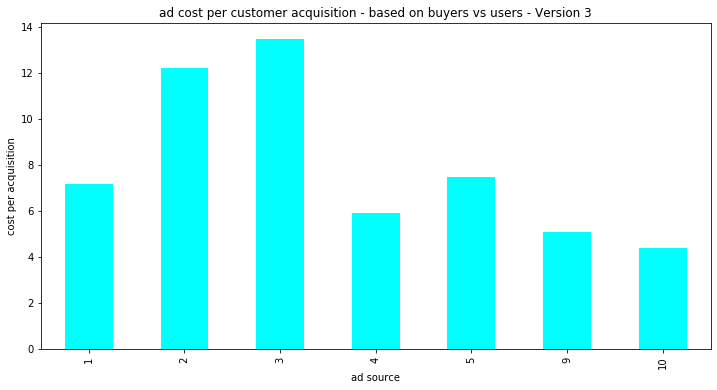

```python
# v3 *
cac_redo_v3_graph = cac_redo_v3['cac'].plot(kind = 'bar', figsize = (12, 6), color = 'cyan')
plt.title('ad cost per customer acquisition - based on buyers vs users - Version 3')
plt.xlabel('ad source')
plt.ylabel('cost per acquisition')
cac_redo_v3_graph.set_xticklabels(cac_redo_v3['source_id'])
plt.show()
```

```python
# V3*
print('cac based on first order stats')
print(cac_redo_v3['cac'].describe())
print('')
```

```
cac based on first order stats
count     7.000000
mean      7.963114
std       3.530511
min       4.381106
25%       5.501789
50%       7.186364
75%       9.838423
max      13.493901
Name: cac, dtype: float64
```

```python
# v2
# buyers_per_source = visits_orders.groupby('source_id').agg({'user_id': 'nunique'}).reset_index()
# buyers_per_source.columns = ['source_id', 'buyers_per_source']
# buyers_per_source

# # v2
# cac_redo = pd.merge(cost_per_source, buyers_per_source, on = 'source_id')
# cac_redo

# # v2
# cac_redo['cac'] = cac_redo['cost_per_source'] / cac_redo['buyers_per_source']
# cac_redo
```

```python
# # v2
# cac_redo_graph = cac_redo['cac'].plot(kind = 'bar', figsize = (12, 6), color = 'cyan')
# plt.title('ad cost per customer acquisition - based on buyers vs users')
# plt.xlabel('ad source')
# plt.ylabel('cost per acquisition')
# cac_redo_graph.set_xticklabels(cac_redo['source_id'])
# plt.show()
```

```python
# v2
# print('cac based on first order stats')
# print(cac_redo['cac'].describe())
# print('')
# # calculate the revenue from the first order month for each cohort
# cohort_first_order_month_revenue = ltv_report.groupby('first_order_month').agg({'ltv':'sum'}).reset_index()
# cohort_first_order_month_revenue.columns = ['first_order_month', 'first_month_revenue']
# # print('first order month revenue per cohort')
# # print(cohort_first_order_month_revenue.describe())
# print('')
# print(cohort_first_order_month_revenue)
```

*How worthwhile where the investments? (ROI)*

- In order to distinguish between payoff for the business and payoff for an ad campaign, ROMI (return on marketing investment) is calculated instead of ROI.
  - ROMI of ad campaign = campaign's gross profit / expenses
- find the profit for each ad source and divide that by the expenses of each ad source

```python
# v1
# costs_per_month.head(2)
```

```python
# v1
# cohort_report.head(2)
```

```python
# v1
# cohort_revenue = cohort_report.groupby('first_session_month').agg({'revenue': 'sum'}).reset_index()
# cohort_revenue.columns = ['cohort', 'revenue']
# cohort_revenue.head()
```

```python
# v1
# cohort_revenue['romi'] = cohort_revenue['revenue'] / costs_per_month['costs_per_month']
# cohort_revenue
```

```python
# v1
# cohort_revenue_graph = cohort_revenue['romi'].plot(kind='bar', figsize = (12, 6), color = 'purple')
# plt.title('ROMI for each cohort')
# plt.xlabel('cohort')
# plt.ylabel('ROMI')
# cohort_revenue_graph.set_xticklabels(cohort_revenue['cohort'])
# plt.show()
```

**Reviewer's comment:** Seems correct, but unfortunately ROMI inherited previous CAC issues. We will probably come back to this step in the next iteration.

**Reviewer's comment v2:** Still the same problem - ROI code is correct, but there is an issue in the CAC part.

**Student's comment:** The ROMI I was calculating before was based on the cohorts. The CAC I calculated is based on the ad sources. - I kept the ROMI for cohorts below (olive green graph) - I calculated the ROMI for the ad sources below (purple graph) I hope this is what you are looking for

```python
source_user_rev.head(2)
```

|  | source_id | user_id | session_start | user_revenue |
| --- | --- | --- | --- | --- |
| 0 | 2 | 313578113262317 | 2017-09-18 22:49:00 | 0.55 |
| 1 | 10 | 1575281904278712 | 2017-06-03 10:13:00 | 3.05 |

```python
cost_per_source
```

|  | source_id | cost_per_source | avg_cost_per_source |
| --- | --- | --- | --- |
| 0 | 1 | 20833.27 | 57.391928 |
| 1 | 2 | 42806.04 | 117.922975 |
| 2 | 3 | 141321.63 | 389.315785 |
| 3 | 4 | 61073.60 | 168.246832 |
| 4 | 5 | 51757.10 | 142.189835 |
| 5 | 9 | 5517.49 | 15.199697 |
| 6 | 10 | 5822.49 | 16.039917 |

```python
# v3 * calculate revene per ad source
revenue_per_source = source_user_rev.groupby('source_id').agg({'user_revenue': 'sum'}).reset_index()
revenue_per_source.columns = ['source_id', 'revenue_per_source']
revenue_per_source
```

|  | source_id | revenue_per_source |
| --- | --- | --- |
| 0 | 1 | 31090.55 |
| 1 | 2 | 46923.61 |
| 2 | 3 | 54511.24 |
| 3 | 4 | 56693.41 |
| 4 | 5 | 52624.02 |
| 5 | 7 | 1.22 |
| 6 | 9 | 5759.40 |
| 7 | 10 | 4450.33 |

```python
# v3 * create a report to calculte the romi of ad sources
romi_report_v3 = pd.merge(cost_per_source, revenue_per_source, on = 'source_id')
romi_report_v3
```

|  | source_id | cost_per_source | avg_cost_per_source | revenue_per_source |
| --- | --- | --- | --- | --- |
| 0 | 1 | 20833.27 | 57.391928 | 31090.55 |
| 1 | 2 | 42806.04 | 117.922975 | 46923.61 |
| 2 | 3 | 141321.63 | 389.315785 | 54511.24 |
| 3 | 4 | 61073.60 | 168.246832 | 56693.41 |
| 4 | 5 | 51757.10 | 142.189835 | 52624.02 |
| 5 | 9 | 5517.49 | 15.199697 | 5759.40 |
| 6 | 10 | 5822.49 | 16.039917 | 4450.33 |

```python
# v3 calculate the romi of ad sources
romi_report_v3['romi'] = romi_report_v3['revenue_per_source'] / romi_report_v3['cost_per_source']
romi_report_v3
```

|  | source_id | cost_per_source | avg_cost_per_source | revenue_per_source | romi |
| --- | --- | --- | --- | --- | --- |
| 0 | 1 | 20833.27 | 57.391928 | 31090.55 | 1.492351 |
| 1 | 2 | 42806.04 | 117.922975 | 46923.61 | 1.096191 |
| 2 | 3 | 141321.63 | 389.315785 | 54511.24 | 0.385725 |
| 3 | 4 | 61073.60 | 168.246832 | 56693.41 | 0.928280 |
| 4 | 5 | 51757.10 | 142.189835 | 52624.02 | 1.016750 |
| 5 | 9 | 5517.49 | 15.199697 | 5759.40 | 1.043844 |
| 6 | 10 | 5822.49 | 16.039917 | 4450.33 | 0.764335 |

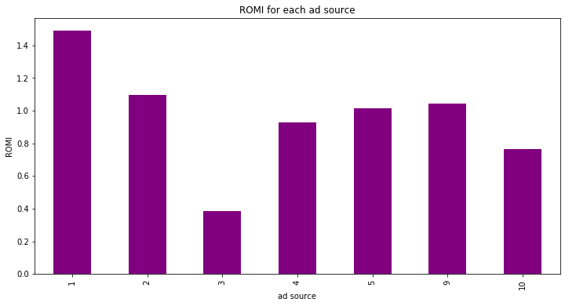

```python
# v3 graph of romi of ad sources
romi_report_v3_graph = romi_report_v3['romi'].plot(kind='bar', figsize = (12, 6), color = 'purple')
plt.title('ROMI for each ad source')
plt.xlabel('ad source')
plt.ylabel('ROMI')
romi_report_v3_graph.set_xticklabels(romi_report_v3['source_id'])
plt.show()
```

**Student's comment:** V3 update: ROMI for Ad Source Conclusion: - ad sources 1, 2, 5, 9, and nearly 4 have had 100% or more return on investment. Ad source 1 has the most return with > 40% profits - ad sources 3 and 10 are doing poorly in terms of returns, with 3 doing the worst, < 40% return

**Student's comment:** Recalculated ROMI based on buyers vs users - see graph below Update: this was ROMI based on Cohorts (Version 2)

```python
# v2 - romi by cohort
# recalc romi - can prob use this table to calculate the same info below:
cohort_revs.head(2)
```

|  | first_order_month | order_month | cohort_revenue |
| --- | --- | --- | --- |
| 0 | 2017-06-01 | 2017-06-01 | 9557.49 |
| 1 | 2017-06-01 | 2017-07-01 | 981.82 |

```python
# v2 - romi by cohort
# recalc
romi_report = cohort_revs.groupby('first_order_month').agg({'cohort_revenue': 'sum'}).reset_index()
romi_report.columns = ['first_order_month', 'cohort_rev_sum']
romi_report
```

|  | first_order_month | cohort_rev_sum |
| --- | --- | --- |
| 0 | 2017-06-01 | 24031.69 |
| 1 | 2017-07-01 | 16127.92 |
| 2 | 2017-08-01 | 11606.26 |
| 3 | 2017-09-01 | 34676.32 |
| 4 | 2017-10-01 | 27603.45 |
| 5 | 2017-11-01 | 26098.99 |
| 6 | 2017-12-01 | 33485.74 |
| 7 | 2018-01-01 | 16663.13 |
| 8 | 2018-02-01 | 16750.50 |
| 9 | 2018-03-01 | 19273.41 |
| 10 | 2018-04-01 | 11810.61 |
| 11 | 2018-05-01 | 13925.76 |

```python
# v2 - romi by cohort
# recacl
romi_report['romi'] = romi_report['cohort_rev_sum'] / costs_per_month['costs_per_month']
romi_report
```

|  | first_order_month | cohort_rev_sum | romi |
| --- | --- | --- | --- |
| 0 | 2017-06-01 | 24031.69 | 1.333982 |
| 1 | 2017-07-01 | 16127.92 | 0.884178 |
| 2 | 2017-08-01 | 11606.26 | 0.784708 |
| 3 | 2017-09-01 | 34676.32 | 1.422974 |
| 4 | 2017-10-01 | 27603.45 | 0.759947 |
| 5 | 2017-11-01 | 26098.99 | 0.688485 |
| 6 | 2017-12-01 | 33485.74 | 0.873951 |
| 7 | 2018-01-01 | 16663.13 | 0.497132 |
| 8 | 2018-02-01 | 16750.50 | 0.511887 |
| 9 | 2018-03-01 | 19273.41 | 0.633675 |
| 10 | 2018-04-01 | 11810.61 | 0.529876 |
| 11 | 2018-05-01 | 13925.76 | 0.626601 |

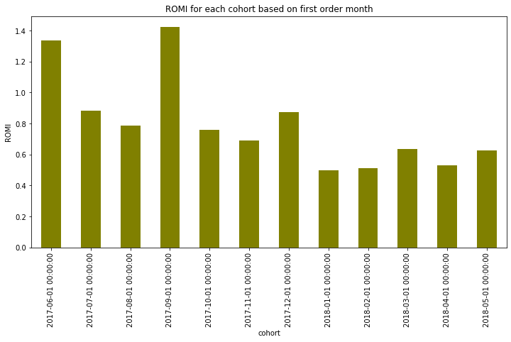

```python
# v2 - romi by cohort
# recalc
romi_report_graph = romi_report['romi'].plot(kind='bar', figsize = (12, 6), color = 'olive')
plt.title('ROMI for each cohort based on first order month')
plt.xlabel('cohort')
plt.ylabel('ROMI')
romi_report_graph.set_xticklabels(romi_report['first_order_month'])
plt.show()
```

**Student's comment:** Conclusion: Recalculated ROMI based on buyers vs users 2 of the cohorts have had a return on investment: 6-2017 (30% profit) and 9-2017 (40% profit), all others have yet to reach this point

*Plot graphs to display how these metrics differ for various devices and ad sources and how they change in time.*

```python
display(visits.head(2))
```

|  | device_type | session_end | source_id | session_start | user_id | session_date | session_week | session_month | session_date_D | session_week_W | session_length_minutes |
| --- | --- | --- | --- | --- | --- | --- | --- | --- | --- | --- | --- |
| 0 | touch | 2017-12-20 17:38:00 | 4 | 2017-12-20 17:20:00 | 16879256277535980062 | 2017-12-20 | 51 | 2017-12-01 | 2017-12-20 | 2017-12-14 | 18.0 |
| 1 | desktop | 2018-02-19 17:21:00 | 2 | 2018-02-19 16:53:00 | 104060357244891740 | 2018-02-19 | 8 | 2018-02-01 | 2018-02-19 | 2018-02-15 | 28.0 |

```python
device_usage_table = visits.pivot_table(index = 'session_month', columns = 'device_type', values = 'user_id', aggfunc = 'nunique')
device_usage_table
```

| device_type session_month | desktop | touch |
| --- | --- | --- |
| 2017-06-01 | 9761 | 3655 |
| 2017-07-01 | 10145 | 4223 |
| 2017-08-01 | 8611 | 3132 |
| 2017-09-01 | 13509 | 5679 |
| 2017-10-01 | 21286 | 8856 |
| 2017-11-01 | 24439 | 8913 |
| 2017-12-01 | 23294 | 8785 |
| 2018-01-01 | 20350 | 8741 |
| 2018-02-01 | 20574 | 8590 |
| 2018-03-01 | 19574 | 8303 |
| 2018-04-01 | 14844 | 6387 |
| 2018-05-01 | 14312 | 6647 |

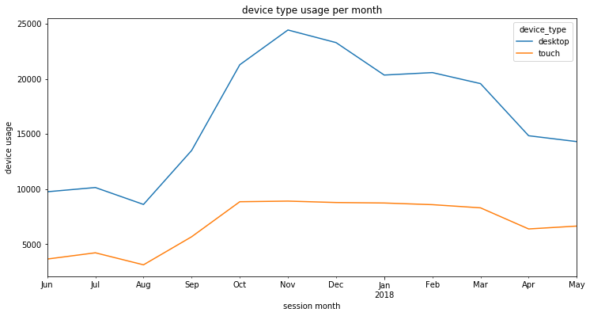

```python
device_usage_table.plot(figsize = (12, 6))
plt.title('device type usage per month')
plt.xlabel('session month')
plt.ylabel('device usage')
plt.show()
```

```python
source_usage_table = visits.pivot_table(index = 'session_month', columns = 'source_id', values = 'user_id', aggfunc = 'nunique')
source_usage_table.fillna('')
```

| source_id session_month | 1 | 2 | 3 | 4 | 5 | 6 | 7 | 9 | 10 |
| --- | --- | --- | --- | --- | --- | --- | --- | --- | --- |
| 2017-06-01 | 972.0 | 1532.0 | 4226.0 | 3636.0 | 2903.0 |  | 2.0 | 753.0 | 427.0 |
| 2017-07-01 | 1047.0 | 1775.0 | 4068.0 | 4114.0 | 3727.0 | 1 | 2.0 | 562.0 | 316.0 |
| 2017-08-01 | 794.0 | 1275.0 | 3416.0 | 3129.0 | 3146.0 | 1 | 1.0 | 613.0 | 244.0 |
| 2017-09-01 | 1395.0 | 2130.0 | 5825.0 | 5377.0 | 4932.0 | 1 | 3.0 | 781.0 | 502.0 |
| 2017-10-01 | 2170.0 | 3350.0 | 8533.0 | 9514.0 | 7525.0 |  | 5.0 | 1043.0 | 926.0 |
| 2017-11-01 | 2790.0 | 4193.0 | 10190.0 | 11228.0 | 6505.0 | 1 | 1.0 | 1488.0 | 888.0 |
| 2017-12-01 | 2735.0 | 3702.0 | 9194.0 | 11787.0 | 6222.0 | 1 | 9.0 | 1234.0 | 621.0 |
| 2018-01-01 | 2142.0 | 3168.0 | 8529.0 | 10247.0 | 5738.0 | 1 | 4.0 | 1059.0 | 925.0 |
| 2018-02-01 | 2121.0 | 3159.0 | 8686.0 | 9756.0 | 5952.0 |  | 3.0 | 1036.0 | 1088.0 |
| 2018-03-01 | 2289.0 | 3353.0 | 7623.0 | 9808.0 | 4613.0 |  | 1.0 | 1772.0 | 1167.0 |
| 2018-04-01 | 1614.0 | 2424.0 | 5473.0 | 7317.0 | 4914.0 |  | 1.0 | 750.0 | 603.0 |
| 2018-05-01 | 1756.0 | 2964.0 | 5343.0 | 7275.0 | 4038.0 |  | 2.0 | 753.0 | 777.0 |

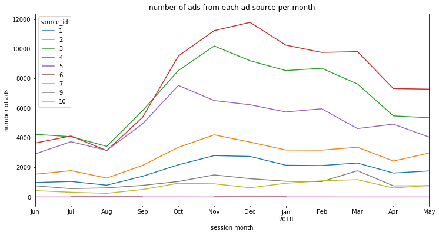

```python
source_usage_table.plot(figsize = (12, 6))
plt.title('number of ads from each ad source per month')
plt.xlabel('session month')
plt.ylabel('number of ads')
plt.show()
```

# 4c Marketing Data Analysis Conclusions

*How much money was spent overtime*

- Actions Performed
- calculated total marketing costs
  - 329,131.62 was spent on marketing

*How much money was spent per ad source?*

- Actions Performed
  - created a new series to calculate the cost per ad source
  - evaluated the cost per ad source stats
  - created a graph of the cost per ad source
- Conclusions
  - There are 7 different ad sources in this data set
  - The average cost per ad source is 47018 dollars, this is high due to the max costs
  - yearly cost ranges from 5517 - 141321 dollars
  - 75% of ad costs were 56415 or less

*How much money was spent over time?*

- Actions Performed
  - created a new column for the month the ad was purchased
  - created a new series to calculate the cost of ads per month
  - evaluated the stats of the cost of ads per month
  - created a graph of the costs of ads per month
- Conclusions
  - the least amount spent on ads was in August: 14790, the most in December: 38315
  - the average cost per month is 27427, this is very close to the median of 27392, suggesting the data is close to a relative distribution

*How much did cusotmer acquisition from each of the sources cost?*

*How worthwhile where the investments? (ROI)*

*Plot graphs to display how these metrics differ for various devices and ad sources and how they change in time.*

- Actions Performed
  - created a table to calculate the device type usage per month
  - created a graph to show the device type usage per month
- Conclusions
  - In general both device types have a trend with a dip in August, an increase with the most use between October - March, and a decrease in April
  - The Desktop type is used much more than the Touch type
- created a table to calculate the number of ads from each source per month
- created a graph to show the number of ads per source per month
  - In general the ad sources share a general trend similar to the device type usage graph, with a dip in August, an increase with the most ads between October - March and a decrease in April
  - Ad sources 4, 3, and 5 have the most ads
    - ad source 3 has the highest cost for customer acquisition, where as 4 and 5 are on the lower end
    - all 3 represent the top 3 highest cost per ad sources

# Additional analysis for Conclusions

```python
# calculate the number ads used by customers for each device type
ad_source_per_device_table = visits.pivot_table(index = 'source_id', columns = 'device_type', values = 'user_id', aggfunc = 'count')
ad_source_per_device_table
```

| device_type source_id | desktop | touch |
| --- | --- | --- |
| 1 | 25901 | 8220 |
| 2 | 35661 | 11965 |
| 3 | 65777 | 19833 |
| 4 | 67640 | 34154 |
| 5 | 50069 | 16836 |
| 6 | 5 | 1 |
| 7 | 28 | 8 |
| 9 | 10119 | 3158 |
| 10 | 7367 | 2658 |

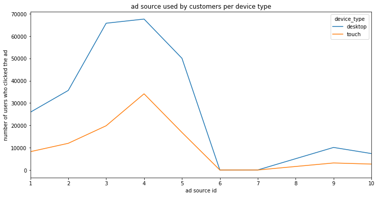

```python
# plot the number of ads used by customers per device type
ad_source_per_device_table.plot(figsize = (12, 6))
plt.title('ad source used by customers per device type')
plt.xlabel('ad source id')
plt.ylabel('number of users who clicked the ad')
plt.show()
```

*Step 3. Write a conclusion: advise marketing experts how much money to invest and where.*

- What sources/platforms would you recommend?
  - Back up your choice:
    - what metrics did you focus on? Why?
    - What conclusions did you draw after finding the metric values?

# Final Conclusions

**Reviewer's comment:** Thank you for the research!